# PaleoACES analysis review

### Observed turnover: Selected-covariance fitted Holocene/Anthropocene group means and contrasts for the primary reconstruction

One primary median-age reconstruction. MA(1) is primary for models containing Holocene observations; Independent and CAR1 are comparisons only. Confidence intervals are conditional on the reconstruction. **Primary reconstruction; conditional inference**.

Script: 12_tracking_era_models.R. Complete PDF (5 pages).

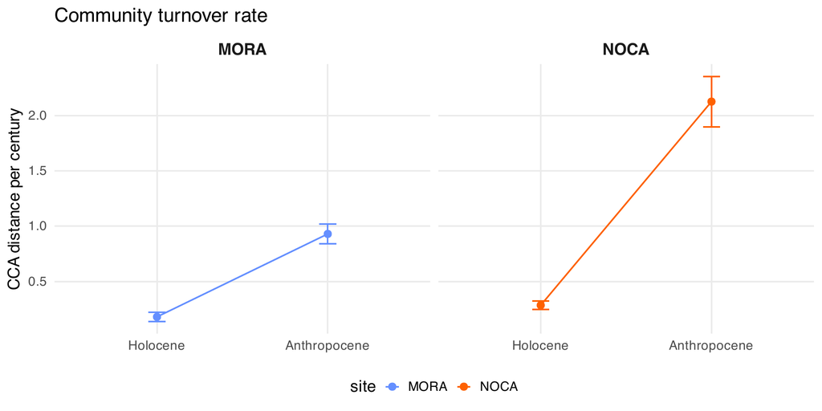

Observed turnover: Selected-covariance fitted Holocene/Anthropocene group means and contrasts for the primary reconstruction. — PDF page 2

### Observed turnover: Selected-covariance coefficients for the primary reconstruction

One primary median-age reconstruction. MA(1) is primary for models containing Holocene observations; Independent and CAR1 are comparisons only. Confidence intervals are conditional on the reconstruction. **Primary reconstruction; conditional inference**.

Script: 12_tracking_era_models.R. Complete PDF (5 pages).

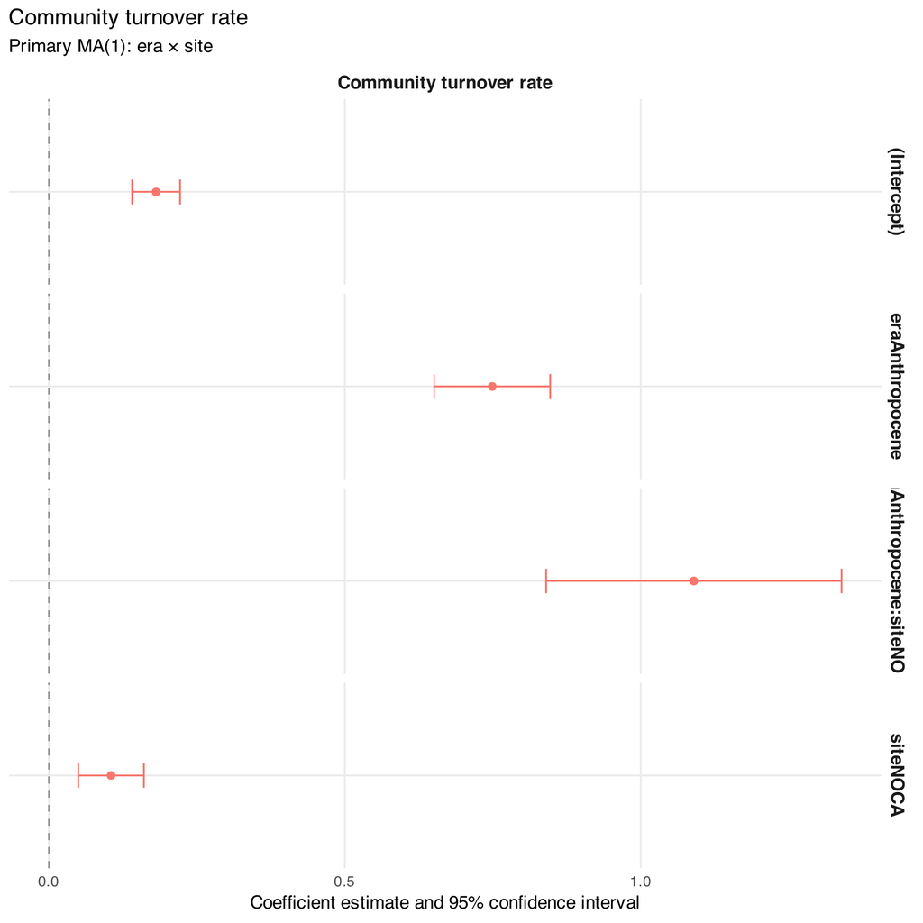

Observed turnover: Selected-covariance coefficients for the primary reconstruction. — PDF page 2

### Observed turnover: Selected-covariance Anthropocene-minus-Holocene contrasts for the primary reconstruction within each park

One primary median-age reconstruction. MA(1) is primary for models containing Holocene observations; Independent and CAR1 are comparisons only. Confidence intervals are conditional on the reconstruction. **Primary reconstruction; conditional inference**.

Script: 12_tracking_era_models.R. Complete PDF (5 pages).

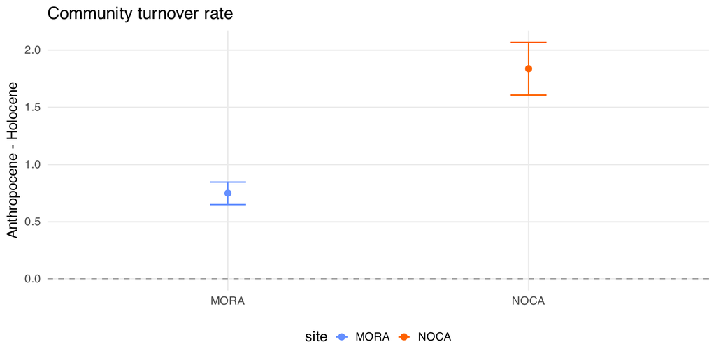

Observed turnover: Selected-covariance Anthropocene-minus-Holocene contrasts for the primary reconstruction within each park. — PDF page 2

### Observed turnover: residual checks for the selected Selected-covariance for the primary reconstruction

One primary median-age reconstruction. MA(1) is primary for models containing Holocene observations; Independent and CAR1 are comparisons only. Confidence intervals are conditional on the reconstruction. **Primary reconstruction; conditional inference**.

Script: 12_tracking_era_models.R. Complete PDF (5 pages).

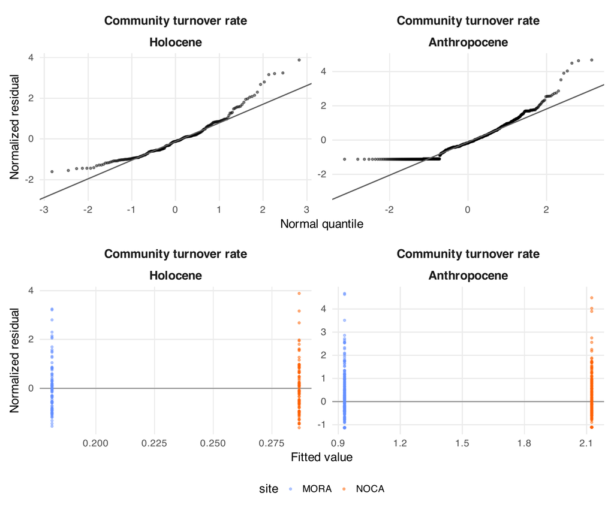

Observed turnover: residual checks for the selected Selected-covariance for the primary reconstruction. — PDF page 2

Complete observed-turnover primary covariance fit results.

### Observed turnover: Selected-covariance individual-lake coefficients for the primary reconstruction

Primary individual-lake comparison with modern plots in its park; the primary MA(1) covariance is reestimated. **Primary reconstruction; conditional inference**.

Script: 13_tracking_lake_sensitivity.R. Complete PDF (5 pages).

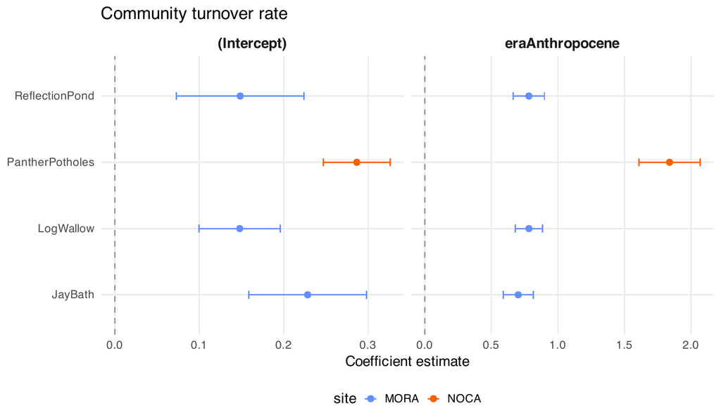

Observed turnover: Selected-covariance individual-lake coefficients for the primary reconstruction. — PDF page 2

### Observed turnover: Selected-covariance Anthropocene-minus-Holocene lake contrasts for the primary reconstruction

Primary individual-lake comparison with modern plots in its park; the primary MA(1) covariance is reestimated. **Primary reconstruction; conditional inference**.

Script: 13_tracking_lake_sensitivity.R. Complete PDF (5 pages).

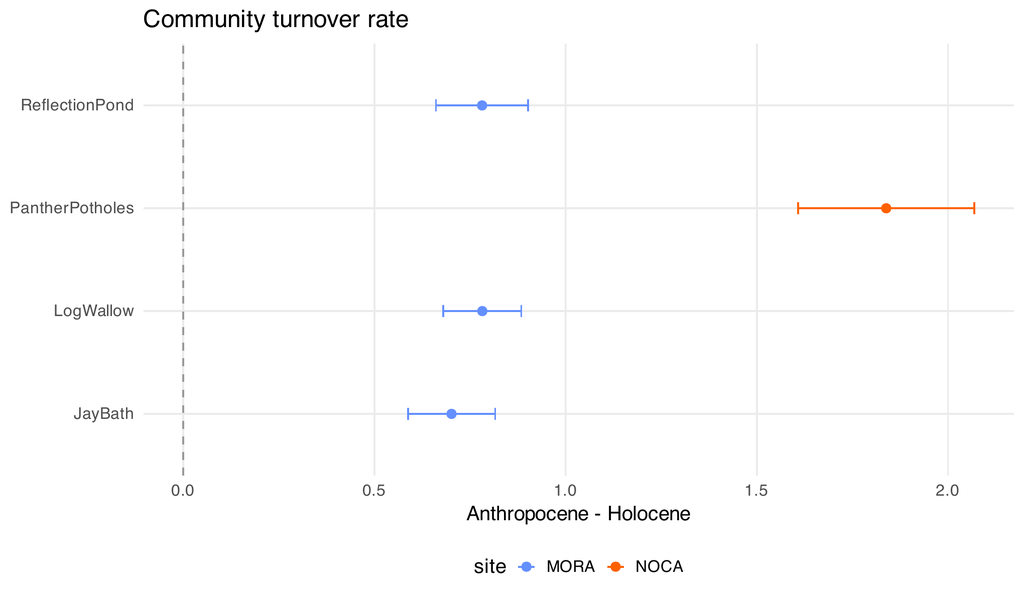

Observed turnover: Selected-covariance Anthropocene-minus-Holocene lake contrasts for the primary reconstruction. — PDF page 2

Complete observed-turnover primary lake sensitivity results.

### Standardized climate-change rate

### Compare independent, neighboring MA(1), and continuous-time AR(1) residual covariance on identical primary observations

One primary median-age reconstruction. MA(1) is primary for models containing Holocene observations; Independent and CAR1 are comparisons only. Confidence intervals are conditional on the reconstruction. **Primary reconstruction; conditional inference**.

Script: 12_tracking_era_models.R. Complete PDF (5 pages).

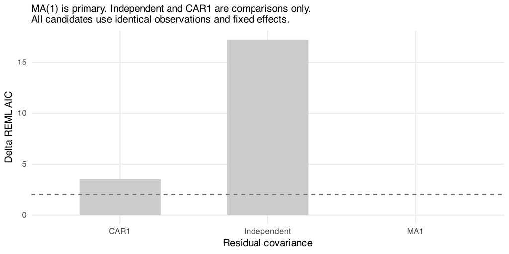

Compare independent, neighboring MA(1), and continuous-time AR(1) residual covariance on identical primary observations. — PDF page 3

### Untransformed physical climate-change rate: Selected-covariance fitted Holocene/Anthropocene group means and contrasts for the primary reconstruction

One primary median-age reconstruction. MA(1) is primary for models containing Holocene observations; Independent and CAR1 are comparisons only. Confidence intervals are conditional on the reconstruction. **Primary reconstruction; conditional inference**.

Script: 12_tracking_era_models.R. Complete PDF (5 pages).

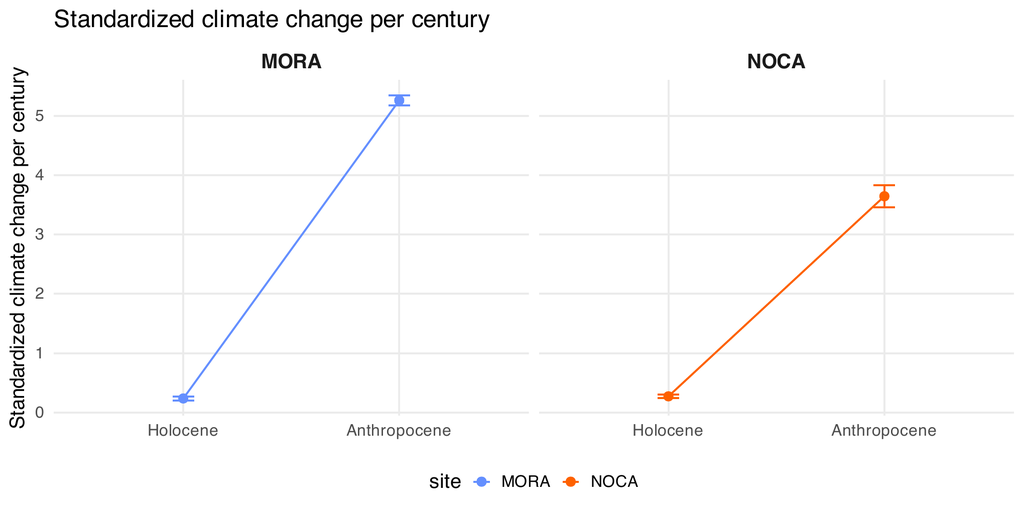

Untransformed physical climate-change rate: Selected-covariance fitted Holocene/Anthropocene group means and contrasts for the primary reconstruction. — PDF page 3

### Untransformed physical climate-change rate: Selected-covariance coefficients for the primary reconstruction

One primary median-age reconstruction. MA(1) is primary for models containing Holocene observations; Independent and CAR1 are comparisons only. Confidence intervals are conditional on the reconstruction. **Primary reconstruction; conditional inference**.

Script: 12_tracking_era_models.R. Complete PDF (5 pages).

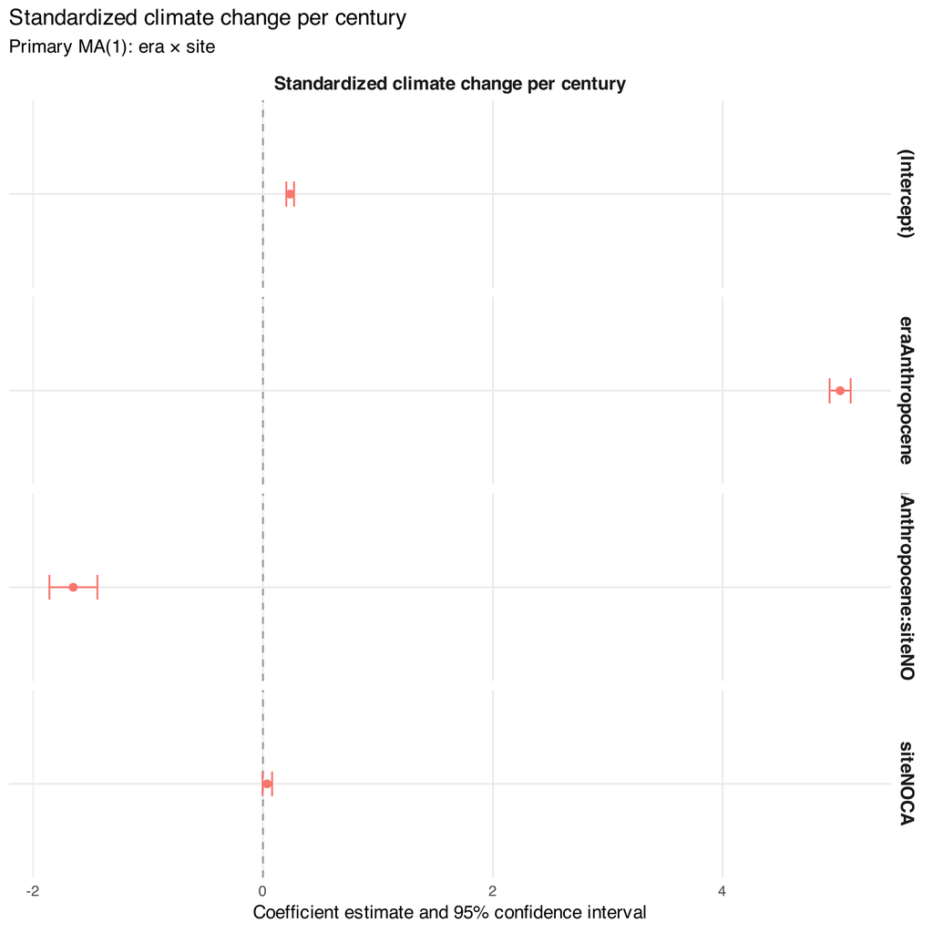

Untransformed physical climate-change rate: Selected-covariance coefficients for the primary reconstruction. — PDF page 3

### Untransformed physical climate-change rate: Selected-covariance Anthropocene-minus-Holocene contrasts for the primary reconstruction within each park

One primary median-age reconstruction. MA(1) is primary for models containing Holocene observations; Independent and CAR1 are comparisons only. Confidence intervals are conditional on the reconstruction. **Primary reconstruction; conditional inference**.

Script: 12_tracking_era_models.R. Complete PDF (5 pages).

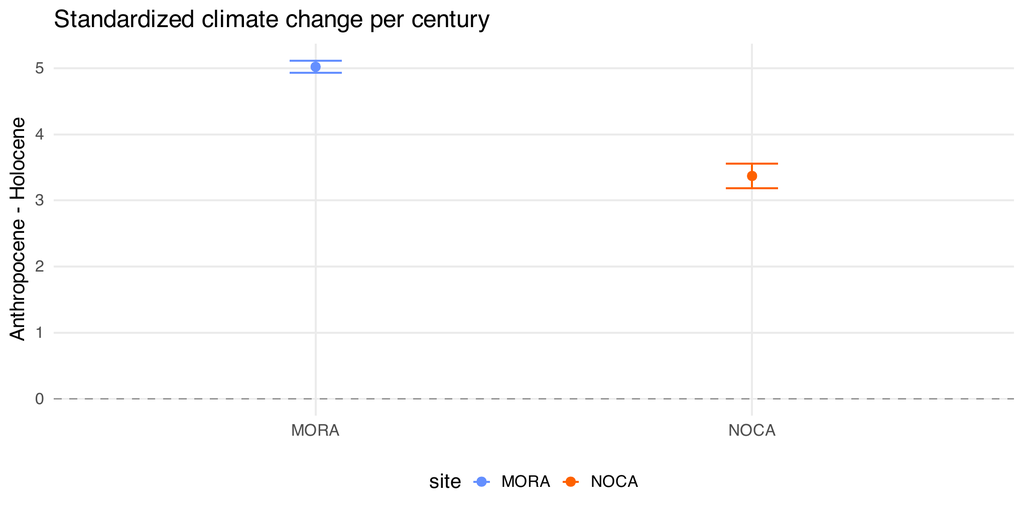

Untransformed physical climate-change rate: Selected-covariance Anthropocene-minus-Holocene contrasts for the primary reconstruction within each park. — PDF page 3

### Untransformed physical climate-change rate: residual checks for the selected Selected-covariance for the primary reconstruction

One primary median-age reconstruction. MA(1) is primary for models containing Holocene observations; Independent and CAR1 are comparisons only. Confidence intervals are conditional on the reconstruction. **Primary reconstruction; conditional inference**.

Script: 12_tracking_era_models.R. Complete PDF (5 pages).

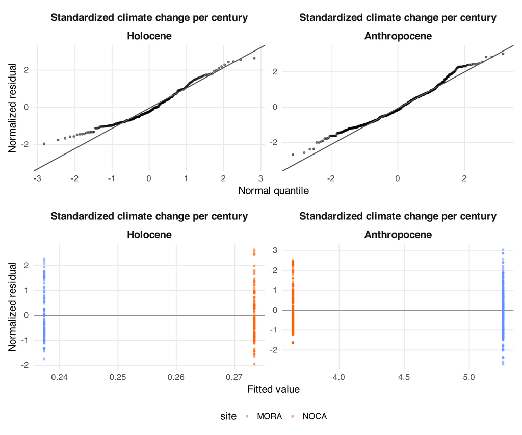

Untransformed physical climate-change rate: residual checks for the selected Selected-covariance for the primary reconstruction. — PDF page 3

Complete raw climate-rate primary covariance fit results.

### Untransformed physical climate-change rate: Selected-covariance individual-lake coefficients for the primary reconstruction

Primary individual-lake comparison with modern plots in its park; the primary MA(1) covariance is reestimated. **Primary reconstruction; conditional inference**.

Script: 13_tracking_lake_sensitivity.R. Complete PDF (5 pages).

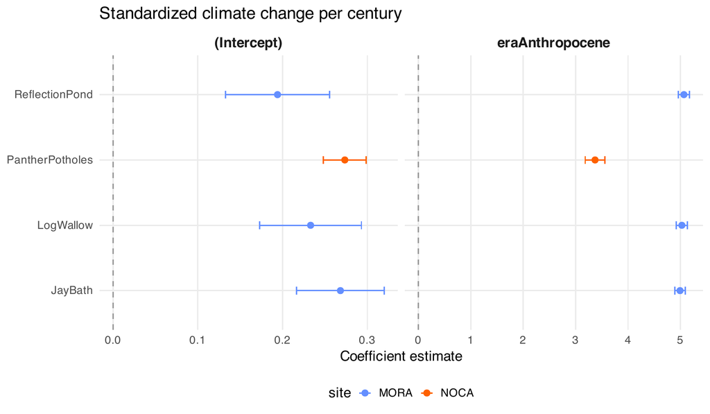

Untransformed physical climate-change rate: Selected-covariance individual-lake coefficients for the primary reconstruction. — PDF page 3

### Untransformed physical climate-change rate: Selected-covariance Anthropocene-minus-Holocene lake contrasts for the primary reconstruction

Primary individual-lake comparison with modern plots in its park; the primary MA(1) covariance is reestimated. **Primary reconstruction; conditional inference**.

Script: 13_tracking_lake_sensitivity.R. Complete PDF (5 pages).

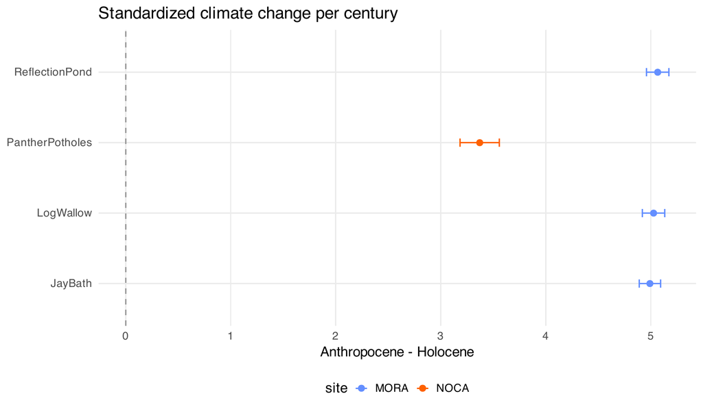

Untransformed physical climate-change rate: Selected-covariance Anthropocene-minus-Holocene lake contrasts for the primary reconstruction. — PDF page 3

Complete raw climate-rate primary lake sensitivity results.

### Pace and direction correction effects

### Compare independent, neighboring MA(1), and continuous-time AR(1) residual covariance on identical primary observations

One primary median-age reconstruction. MA(1) is primary for models containing Holocene observations; Independent and CAR1 are comparisons only. Confidence intervals are conditional on the reconstruction. **Primary reconstruction; conditional inference**.

Script: 12_tracking_era_models.R. Complete PDF (5 pages).

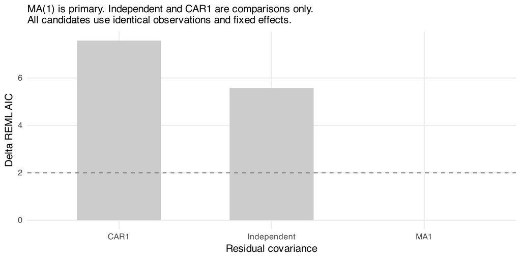

Compare independent, neighboring MA(1), and continuous-time AR(1) residual covariance on identical primary observations. — PDF page 4

### Pace correction effect: group means for the primary reconstruction

One primary median-age reconstruction. MA(1) is primary for models containing Holocene observations; Independent and CAR1 are comparisons only. Confidence intervals are conditional on the reconstruction. **Primary reconstruction; conditional inference**.

Script: 12_tracking_era_models.R. Complete PDF (5 pages).

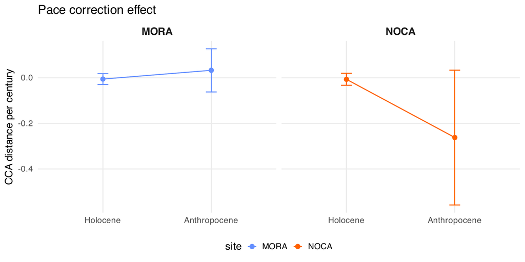

Pace correction effect: group means for the primary reconstruction. — PDF page 4

### Pace correction effect: coefficients for the primary reconstruction

One primary median-age reconstruction. MA(1) is primary for models containing Holocene observations; Independent and CAR1 are comparisons only. Confidence intervals are conditional on the reconstruction. **Primary reconstruction; conditional inference**.

Script: 12_tracking_era_models.R. Complete PDF (5 pages).

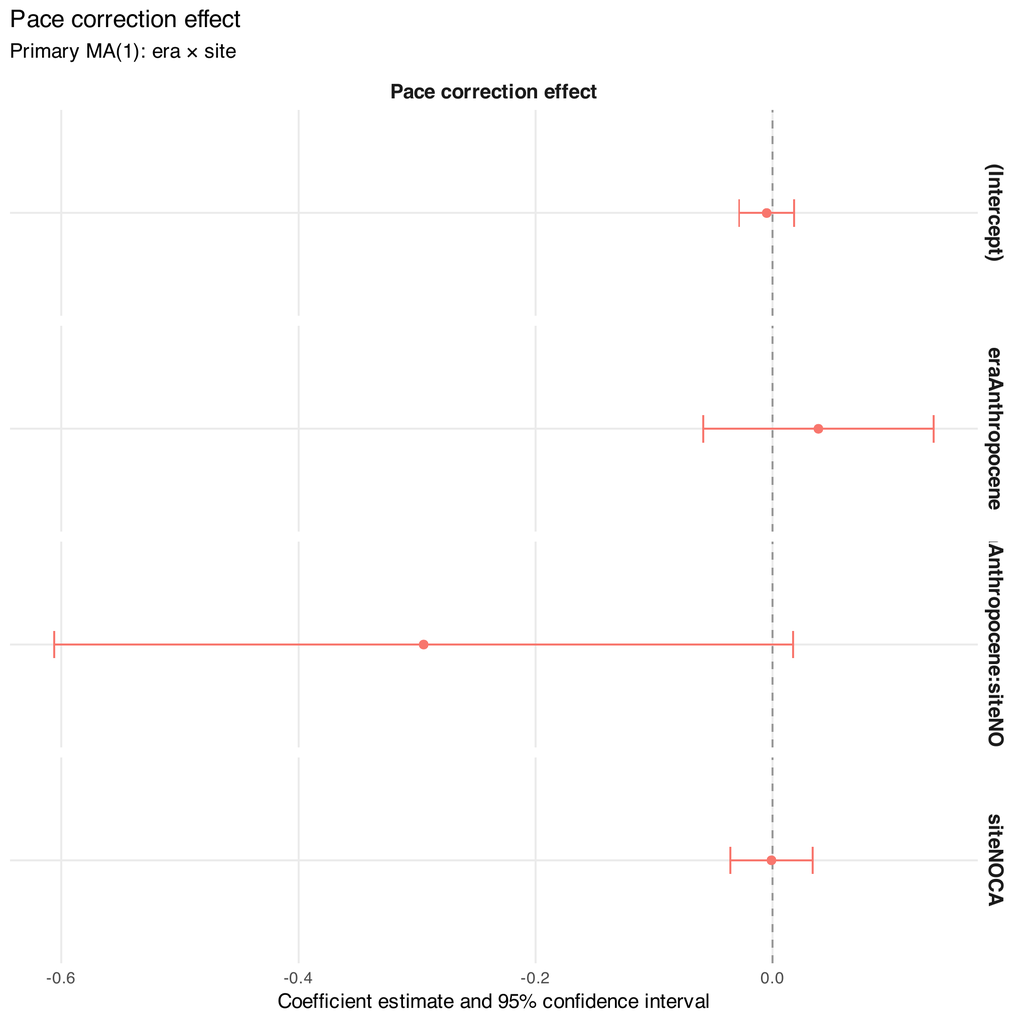

Pace correction effect: coefficients for the primary reconstruction. — PDF page 4

### Pace correction effect: contrasts for the primary reconstruction

One primary median-age reconstruction. MA(1) is primary for models containing Holocene observations; Independent and CAR1 are comparisons only. Confidence intervals are conditional on the reconstruction. **Primary reconstruction; conditional inference**.

Script: 12_tracking_era_models.R. Complete PDF (5 pages).

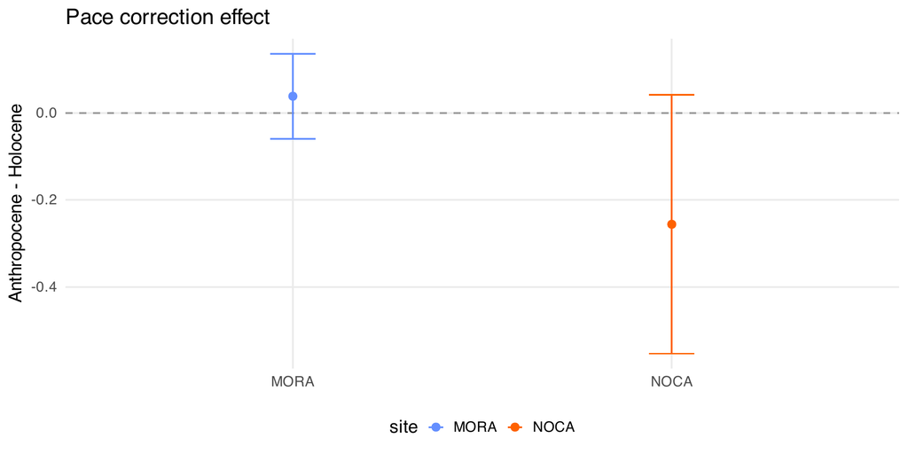

Pace correction effect: contrasts for the primary reconstruction. — PDF page 4

### Pace correction effect: residuals for the primary reconstruction

One primary median-age reconstruction. MA(1) is primary for models containing Holocene observations; Independent and CAR1 are comparisons only. Confidence intervals are conditional on the reconstruction. **Primary reconstruction; conditional inference**.

Script: 12_tracking_era_models.R. Complete PDF (5 pages).

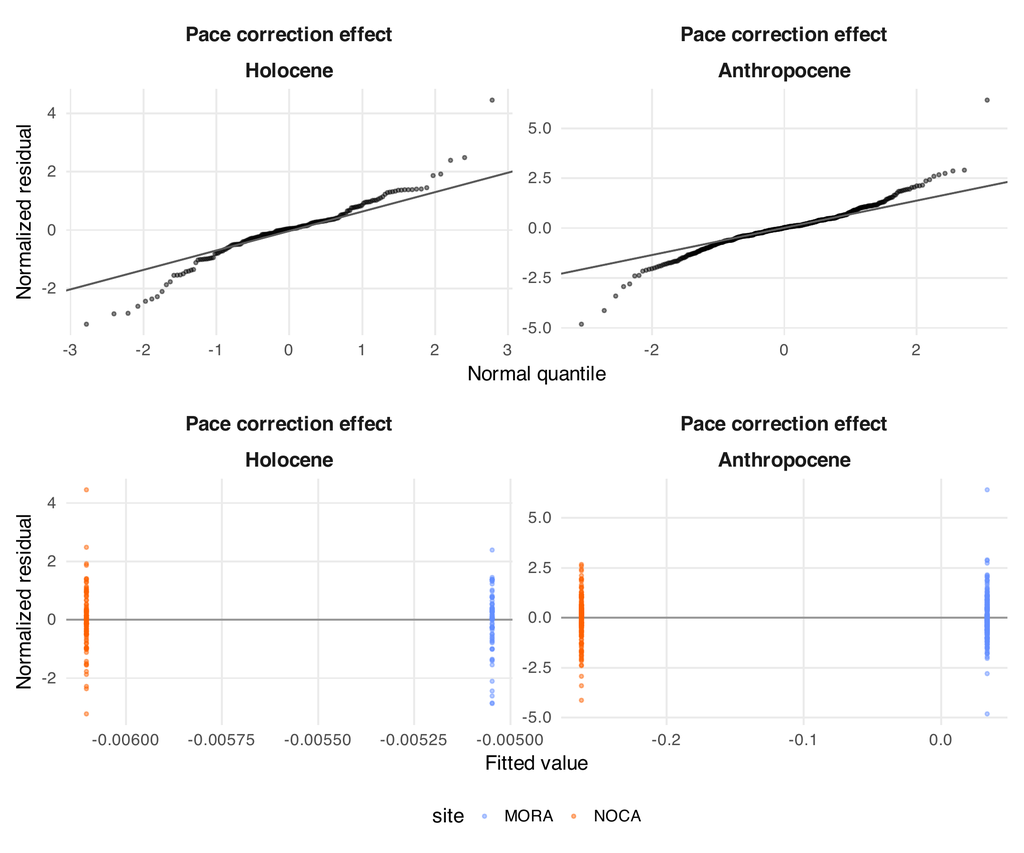

Pace correction effect: residuals for the primary reconstruction. — PDF page 4

Complete pace correction effect model results.

### Pace correction effect: primary lake sensitivity coefficients

Primary individual-lake comparison with modern plots in its park; the primary MA(1) covariance is reestimated. **Primary reconstruction; conditional inference**.

Script: 13_tracking_lake_sensitivity.R. Complete PDF (5 pages).

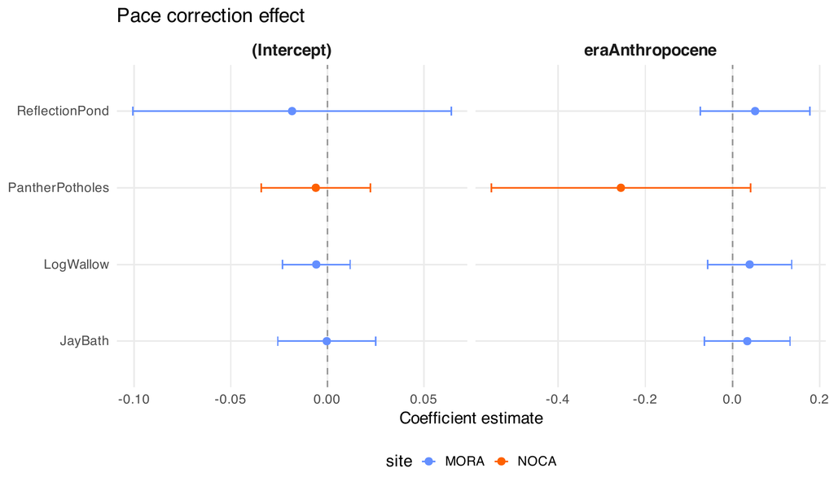

Pace correction effect: primary lake sensitivity coefficients. — PDF page 4

### Pace correction effect: primary lake sensitivity contrasts

Primary individual-lake comparison with modern plots in its park; the primary MA(1) covariance is reestimated. **Primary reconstruction; conditional inference**.

Script: 13_tracking_lake_sensitivity.R. Complete PDF (5 pages).

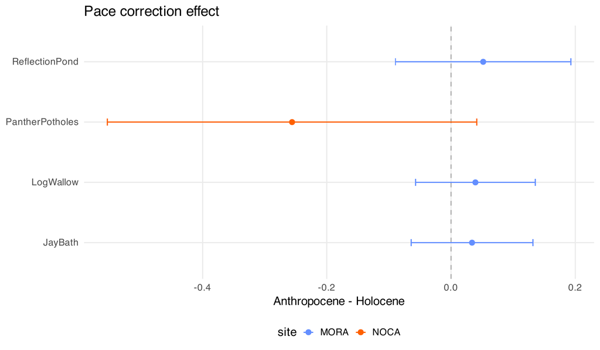

Pace correction effect: primary lake sensitivity contrasts. — PDF page 4

Complete pace correction effect lake results.

### Compare independent, neighboring MA(1), and continuous-time AR(1) residual covariance on identical primary observations

One primary median-age reconstruction. MA(1) is primary for models containing Holocene observations; Independent and CAR1 are comparisons only. Confidence intervals are conditional on the reconstruction. **Primary reconstruction; conditional inference**.

Script: 12_tracking_era_models.R. Complete PDF (5 pages).

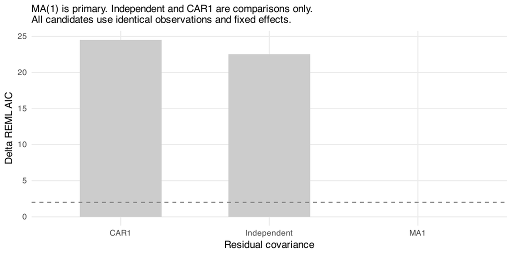

Compare independent, neighboring MA(1), and continuous-time AR(1) residual covariance on identical primary observations. — PDF page 5

### Direction correction effect: group means for the primary reconstruction

One primary median-age reconstruction. MA(1) is primary for models containing Holocene observations; Independent and CAR1 are comparisons only. Confidence intervals are conditional on the reconstruction. **Primary reconstruction; conditional inference**.

Script: 12_tracking_era_models.R. Complete PDF (5 pages).

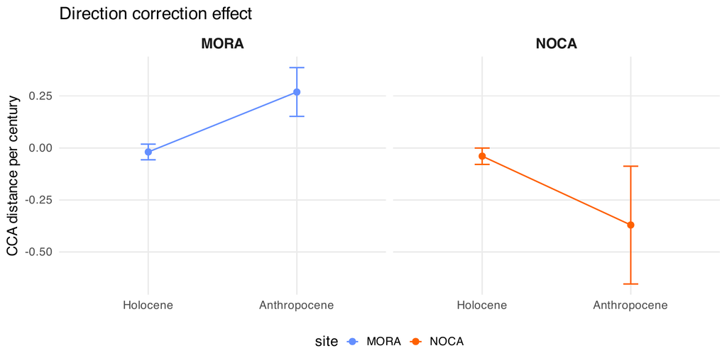

Direction correction effect: group means for the primary reconstruction. — PDF page 5

### Direction correction effect: coefficients for the primary reconstruction

One primary median-age reconstruction. MA(1) is primary for models containing Holocene observations; Independent and CAR1 are comparisons only. Confidence intervals are conditional on the reconstruction. **Primary reconstruction; conditional inference**.

Script: 12_tracking_era_models.R. Complete PDF (5 pages).

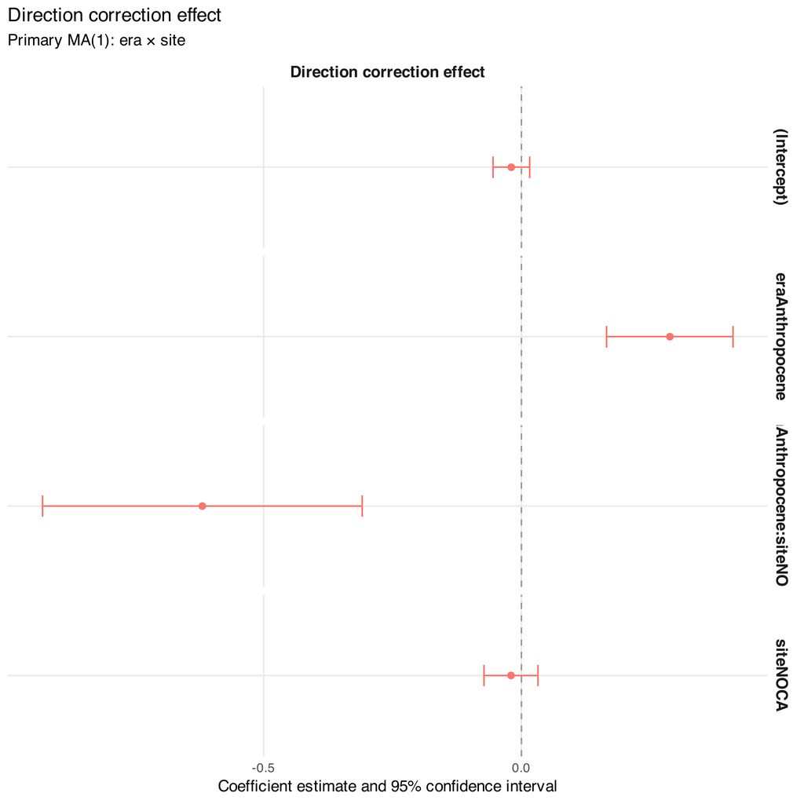

Direction correction effect: coefficients for the primary reconstruction. — PDF page 5

### Direction correction effect: contrasts for the primary reconstruction

One primary median-age reconstruction. MA(1) is primary for models containing Holocene observations; Independent and CAR1 are comparisons only. Confidence intervals are conditional on the reconstruction. **Primary reconstruction; conditional inference**.

Script: 12_tracking_era_models.R. Complete PDF (5 pages).

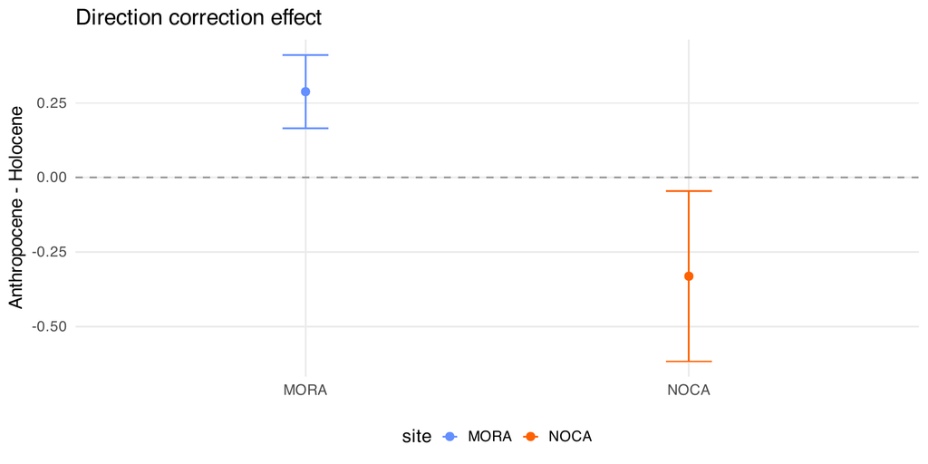

Direction correction effect: contrasts for the primary reconstruction. — PDF page 5

### Direction correction effect: residuals for the primary reconstruction

One primary median-age reconstruction. MA(1) is primary for models containing Holocene observations; Independent and CAR1 are comparisons only. Confidence intervals are conditional on the reconstruction. **Primary reconstruction; conditional inference**.

Script: 12_tracking_era_models.R. Complete PDF (5 pages).

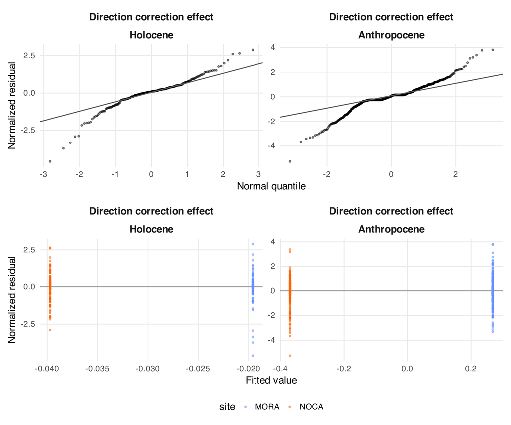

Direction correction effect: residuals for the primary reconstruction. — PDF page 5

Complete direction correction effect model results.

### Direction correction effect: primary lake sensitivity coefficients

Primary individual-lake comparison with modern plots in its park; the primary MA(1) covariance is reestimated. **Primary reconstruction; conditional inference**.

Script: 13_tracking_lake_sensitivity.R. Complete PDF (5 pages).

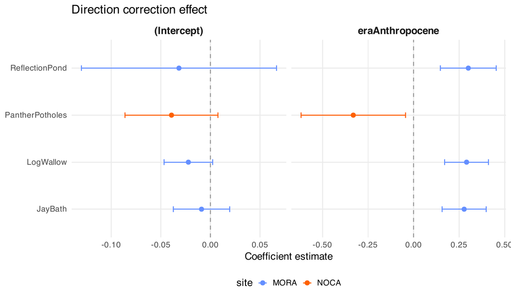

Direction correction effect: primary lake sensitivity coefficients. — PDF page 5

### Direction correction effect: primary lake sensitivity contrasts

Primary individual-lake comparison with modern plots in its park; the primary MA(1) covariance is reestimated. **Primary reconstruction; conditional inference**.

Script: 13_tracking_lake_sensitivity.R. Complete PDF (5 pages).

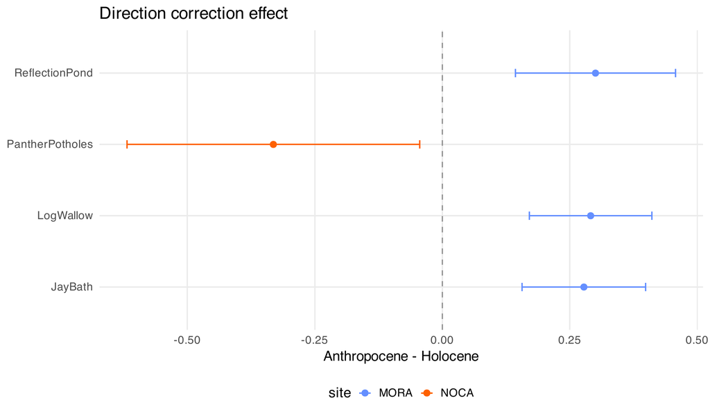

Direction correction effect: primary lake sensitivity contrasts. — PDF page 5

Complete direction correction effect lake results.

### Joint pace/direction correction model

The separate response models above remain intact. The additional joint model includes **pace and direction correction effects only**, with all era × park × correction interactions:

```r
fit_joint = nlme::gls(
  estimate ~ era * site * correction,
  correlation = corPairedMA1(form = ~ time_index | series),
  weights = nlme::varIdent(form = ~ 1 | era_site_correction),
  data = paired_corrections,
  method = "REML"
)
```

`corPairedMA1()` is the validated shared correlation helper. Its temporal part is MA(1) on the original transition indices; its outcome part allows the two corrections on the same transition to correlate, separately by era/park. Their product defines the full within-series correlation. Modern plots have two outcomes but one time point each. Separate residual SDs apply to the eight era/park/correction groups. Stacking the two corrections as independent observations would give incorrect contrast uncertainty.

Only transitions with both corrections defined enter: 185 Holocene transitions (78 MORA, 107 NOCA) and 465 modern pairs (254 MORA, 211 NOCA), giving 1,300 response rows. No values are imputed and temporal indices are not renumbered. These paired fitted means can differ from separate-model means, which retain each response’s own eligible records. This joint model is primary-only. Convergence, boundary estimates and covariance uncertainty are reported with the current fit below.

| Era | Park | Direction − Pace | 95% lower | 95% upper | Holm p | Stars |
| --- | --- | --- | --- | --- | --- | --- |
| Holocene | MORA | -0.02115 | -0.07303 | 0.03073 | 0.4161 | — |
| Anthropocene | MORA | 0.3155 | 0.1322 | 0.4988 | 0.003264 | ** |
| Holocene | NOCA | -0.03324 | -0.07496 | 0.008478 | 0.3487 | — |
| Anthropocene | NOCA | -0.2246 | -0.5292 | 0.08002 | 0.3487 | — |

Differences are **Direction − Pace**, in CCA distance per century. P-values are Holm-adjusted across the four within-era/park comparisons; intervals are unadjusted conditional 95% intervals. Current estimates and significance appear in the table above; they are refitted to correction effects, not copied from the retired corrected-lag responses. Correction-by-era interaction p-values use their own Holm family of two park comparisons. Positive effects mean the correction reduces final lag; a positive Direction − Pace contrast means the direction correction provides the larger reduction.

Joint coefficients, fitted means, correction comparisons, era comparisons, correction-by-era interactions, displayed mean tests against zero, matched input, and excluded unmatched records.

Complete paired correction GLS results, means and contrast tests.

### Paired pace/direction model normalized-residual diagnostics

Joint era × park × correction GLS on transitions with both corrections defined. Temporal MA(1) and paired correction correlation are modeled together; normalized residuals account for the full fitted covariance. **Primary reconstruction; conditional inference**.

Script: 12_tracking_era_models.R. Complete PDF (1 page).

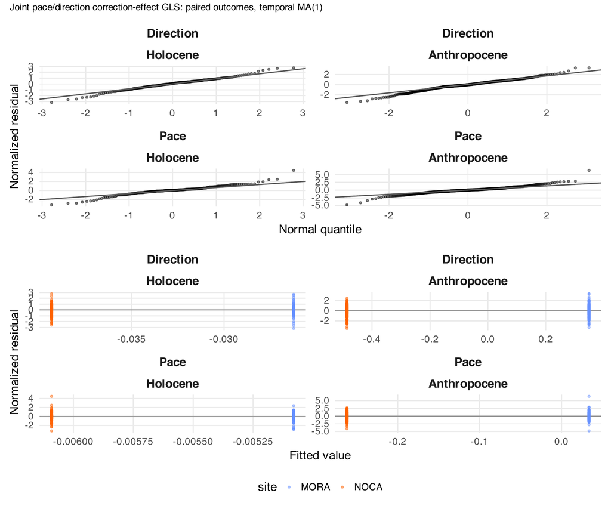

Paired pace/direction model normalized-residual diagnostics — PDF page 1

## Manuscript comparison from the primary reconstruction

Figure 4 has four labeled sections: **A**, standardized climate era contrasts; **B**, community-turnover and observed-lag era contrasts; **C**, Holocene lag distributions; **D**, Anthropocene lag distributions. Panels C/D have MORA and NOCA on the x-axis and their own era-specific scales. The y-axis is **CCA distance per century**. The legend identifies **Observed lag-change rate** (green), **Pace correction effect rate** (pink), and **Direction correction effect rate** (purple). Filled small dots and capped error bars show fitted means and conditional 95% Satterthwaite intervals. Large signed numerical annotations label the means to three decimals.

Observed violins and means use the existing observed-response model and all its eligible records (211 Holocene transitions, 607 modern pairs). Correction-effect violins and means use the new joint model’s complete paired records; observed is **not** a third joint-model level. Each input observation enters once within its displayed response.

Stars on mean labels test whether that mean differs from **zero**, using unadjusted two-sided Satterthwaite t tests: * p < 0.05, ** p < 0.01, *** p < 0.001. Non-significant mean points, intervals and labels are faded; transparency has no legend entry. Brackets compare **direction minus pace**, and are shown only where their Holm-adjusted comparison is significant; the bracket labels report the difference, stars and adjusted p-value. These are different tests: a direction-effect mean can differ from zero even if its difference from pace is unsupported.

The correction-effect responses are existing geometric quantities:

- `pace_effect_on_lag_per_century = (observed final lag − pace-corrected final lag) × 100 / elapsed climate years`.
- `direction_effect_on_lag_per_century = (observed final lag − direction-corrected final lag) × 100 / elapsed climate years`.

Thus positive means indicate a lag reduction from the correction, negative means indicate a lag increase, and zero indicates no effect. These are different from corrected lag-change rates measured relative to initial lag. Both effects are independently verified from endpoints, and undefined counterfactual directions remain excluded only for the affected response.

Correction-effect era contrasts from the separate models remain a separate figure. The top-row climate, turnover and observed-lag contrasts retain their original definitions. Signed fitted-mean ratios are descriptive and can be unstable near a zero mean.

### Figure 4. Primary era contrasts, observed lag change and correction effects

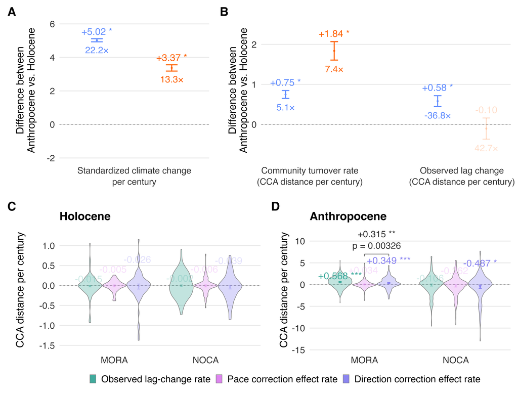

Figure 4. fig tracking era distributions

Full PDF · Figure script.

### Primary correction-effect era contrasts

Selected primary GLS Anthropocene-minus-Holocene contrasts for pace- and direction correction effects, with conditional 95% Satterthwaite intervals in CCA distance per century. MORA/NOCA are blue/orange; correction labels retain their colors. Stars mark unadjusted p < 0.05; nonsignificant dots, bars and annotations are faint. Signed fitted-mean ratios are descriptive and can be unstable near zero. Bacon model sensitivity is currently on hold. **Primary reconstruction; conditional inference**.

Script: 14_tracking_manuscript_figure.R. Complete PDF (1 page).

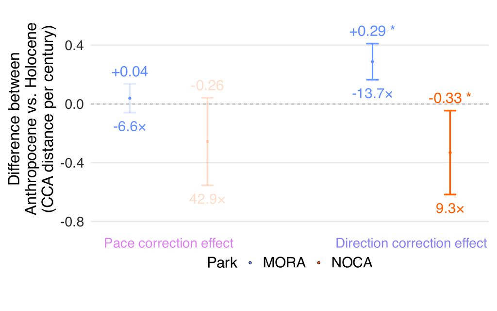

Primary correction-effect era contrasts — PDF page 1

## Within-era climate, fire and elevation predictor models

Primary Holocene explanatory models fit observed lag-change rate and the two correction-effect rates against `site + climate_rate + fire_activity`, with site-specific residual variances and selected covariance. Primary Anthropocene basic models use `site + burned`; extended community models also include `elevation + climate_rate`. Responses remain untransformed. Modern-only models retain independent residuals.

The main coefficient figure compares **Holocene** and **Anthropocene** predictor effects on **observed lag-change rate**, **pace correction effect** and **direction correction effect**, shown in green, pink and purple respectively. The site coefficient is **NOCA − MORA**. These additive models have shared climate/fire slopes across parks, so the figure does not present duplicated slopes as separate park estimates. Holocene fire is the effect of one additional event per century per eligible core; Anthropocene fire is **burned − unburned**. The Anthropocene main figure uses `site + burned`. Intercepts are omitted, and conditional 95% intervals accompany the coefficients. Each era’s caption gives each response model’s descriptive R² (`1 − SSE/SST`); negative values are retained because GLS minimizes a covariance-weighted criterion rather than ordinary SSE. The eras have separate coefficient-axis scales. Coefficients refer to their stated predictor increments, not standardized effect sizes.

### Figure 5. Site, climate and fire effects on lag-change rates by era

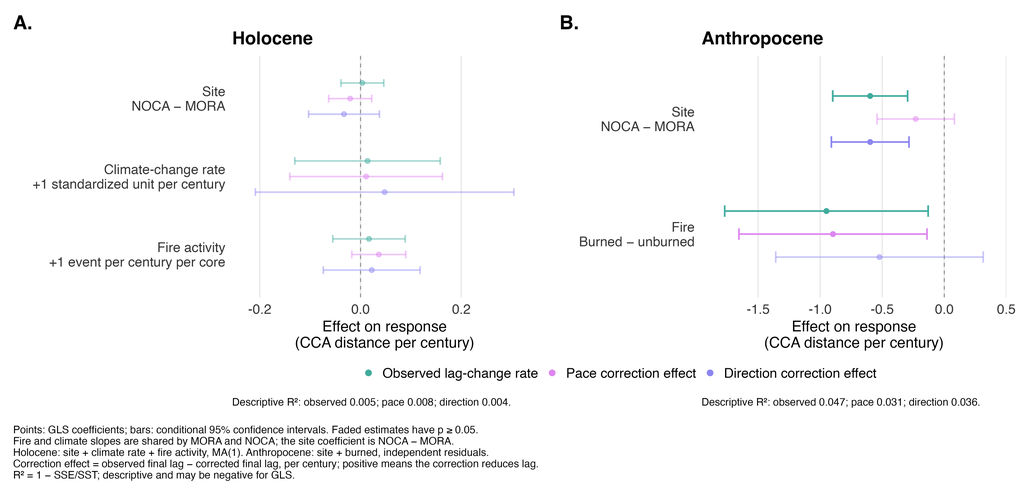

Figure 5. fig tracking predictor era coefficients

Full PDF · Figure script.

### Appendix: extended Anthropocene coefficients

The `site + elevation + climate_rate + burned` model remains fitted and reported as an appendix analysis. Its separate figure omits intercepts and shows elevation effects per 100 m for readability, without changing the fitted model or its original coefficient table. Its caption gives the three extended-model R² values.

### Appendix: extended Anthropocene predictor coefficients

Site + elevation + climate-change rate + burned, with independent residuals and park-specific residual variances. Intercepts are omitted. Elevation is displayed per 100 m; model fitting uses the original untransformed covariates. Conditional 95% intervals and descriptive R² are shown for observed lag change, pace correction effect and direction correction effect. **Primary reconstruction; conditional inference**.

Script: 15_tracking_predictor_models.R. Complete PDF (1 page).

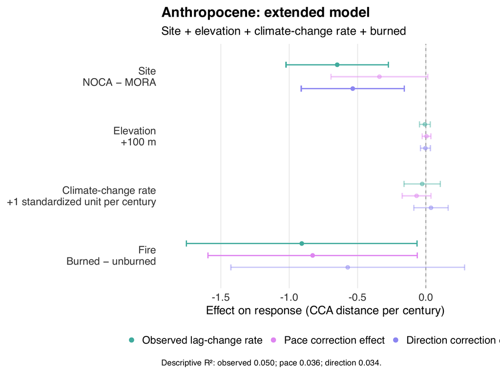

Appendix: extended Anthropocene predictor coefficients — PDF page 1

### Model diagnostics and lake sensitivity

The lake random-intercept sensitivity uses the same primary observations and selected covariance. Its actual variance, coefficient changes and covariance-interval status are reported below; the older near-zero variance result is not assumed to recur.

| Response | Lake SD | Maximum coefficient change | Covariance uncertainty | Lake-SD interval available |
| --- | --- | --- | --- | --- |
| lag_rate_per_century | 0.01664 | 0.02304 | positive_definite | TRUE |
| pace_effect_on_lag_per_century | 3.051e-06 | 2.247e-09 | Non-positive definite approximate variance-covariance | FALSE |
| direction_effect_on_lag_per_century | 5.675e-06 | 1.167e-10 | Non-positive definite approximate variance-covariance | FALSE |

### Holocene predicted lag-change trajectories

Primary explanatory models with actual transition durations and matching climate/fire exposures. Bacon model sensitivity is currently on hold. **Primary reconstruction; conditional inference**.

Script: 15_tracking_predictor_models.R. Complete PDF (1 page).

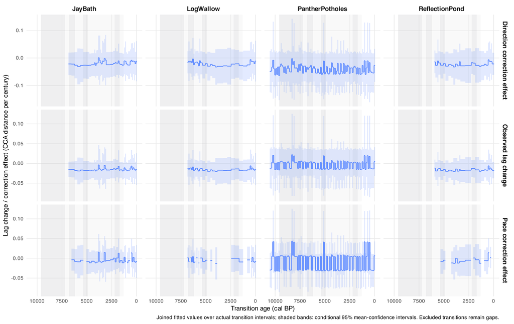

Holocene predicted lag-change trajectories — PDF page 1

| Response | Specification | Observations | Descriptive R² |
| --- | --- | --- | --- |
| lag_rate_per_century | Holocene | 210 | 0.00512 |
| lag_rate_per_century | Anthropocene_basic | 607 | 0.04691 |
| lag_rate_per_century | Anthropocene_extended | 607 | 0.05036 |
| pace_effect_on_lag_per_century | Holocene | 184 | 0.007669 |
| pace_effect_on_lag_per_century | Anthropocene_basic | 465 | 0.03058 |
| pace_effect_on_lag_per_century | Anthropocene_extended | 465 | 0.03579 |
| direction_effect_on_lag_per_century | Holocene | 210 | 0.003899 |
| direction_effect_on_lag_per_century | Anthropocene_basic | 607 | 0.03587 |
| direction_effect_on_lag_per_century | Anthropocene_extended | 607 | 0.03433 |

### Descriptive R² for the predictor models

Primary explanatory models with actual transition durations and matching climate/fire exposures. Bacon model sensitivity is currently on hold. **Primary reconstruction; conditional inference**.

Script: 15_tracking_predictor_models.R. Complete PDF (1 page).

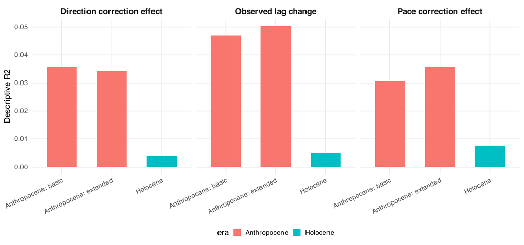

Descriptive R² for the predictor models — PDF page 1

### Predictor-model normalized residual diagnostics

Primary explanatory models with actual transition durations and matching climate/fire exposures. Bacon model sensitivity is currently on hold. **Primary reconstruction; conditional inference**.

Script: 15_tracking_predictor_models.R. Complete PDF (1 page).

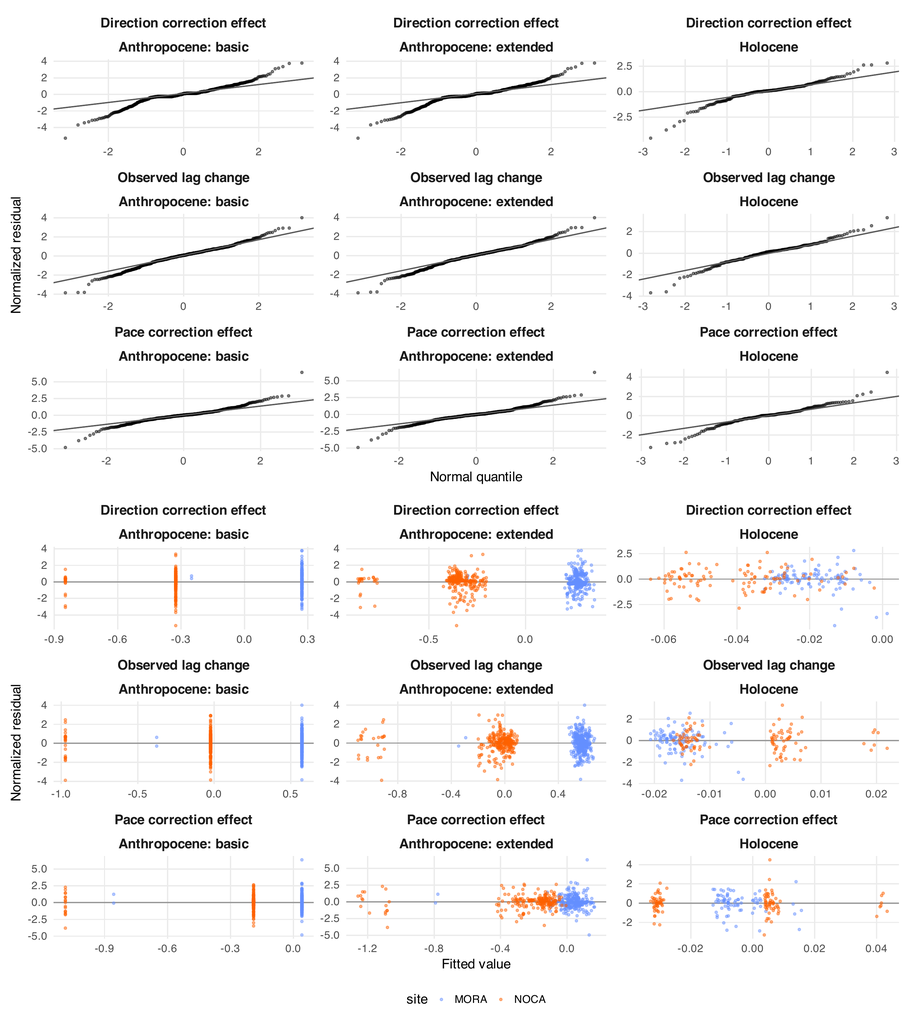

Predictor-model normalized residual diagnostics — PDF page 1

Complete era-specific predictor results, lake sensitivity.

Bacon model sensitivity is **on hold for both community and species models** and omitted from the active review. The code and saved checkpoints are retained for a later rerun; normal workflow and standalone model-stage runs do not execute these sensitivities. The reported coefficients and intervals condition on the primary median-age reconstruction; they do not additionally propagate chronology uncertainty. Stored Bacon chronologies remain unchanged and continue to supply the primary sample median ages.

## Species and seasonal climate contributions

Species vectors use changes in mean normalized sample weights and fixed species coordinates. They sum exactly to delta WA before projections and rates. Species parallel contributions are signed along delta LC and expressed per century. Seasonal climate-variable vectors are one-variable LC perturbations; their sum equals delta LC, and their projections along delta WA retain displacement units. Undefined directions stay NA. Perpendicular contributions remain retired.

Boxplots use one primary transition per species/variable and one modern pair, without flattening chronology reconstructions into observations. The same conservation checks run within each draw. These distributions describe differences among actual transitions, rather than uncertainty across offsets or Bacon draws. Climate displacements retain their actual, variable-duration endpoints.

### Species contribution rates by era and park

Each primary lake transition and each modern plot pair contributes once per component. Boxes describe variation among actual transitions, not among offsets or Bacon draws. Species contributions are rates; climate contributions remain displacements. Undefined reference directions are omitted, with counts retained.

Script: 16_cca_transition_contributions.R. Complete PDF (1 page).

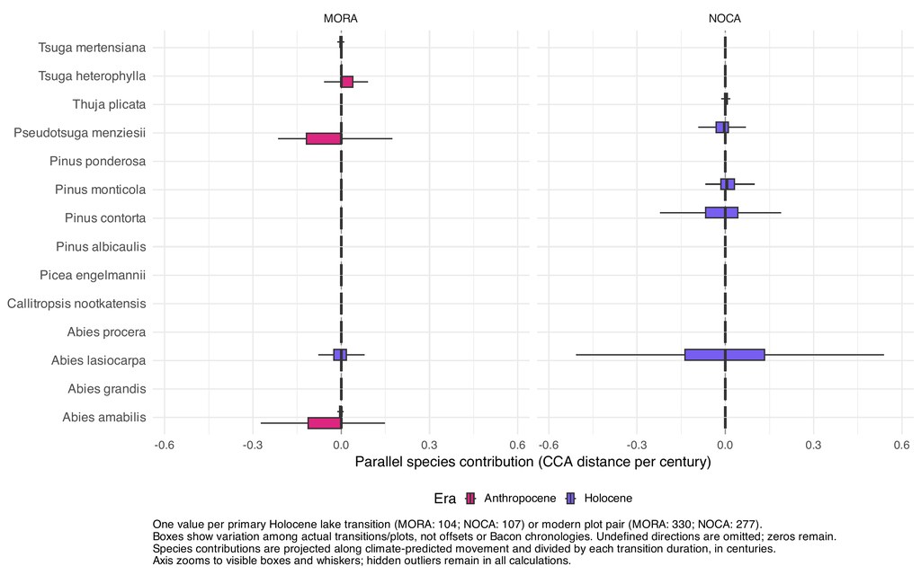

Species contribution rates by era and park. — PDF page 1

### Seasonal climate displacement contributions by era and park

Each primary lake transition and each modern plot pair contributes once per component. Boxes describe variation among actual transitions, not among offsets or Bacon draws. Species contributions are rates; climate contributions remain displacements. Undefined reference directions are omitted, with counts retained.

Script: 16_cca_transition_contributions.R. Complete PDF (1 page).

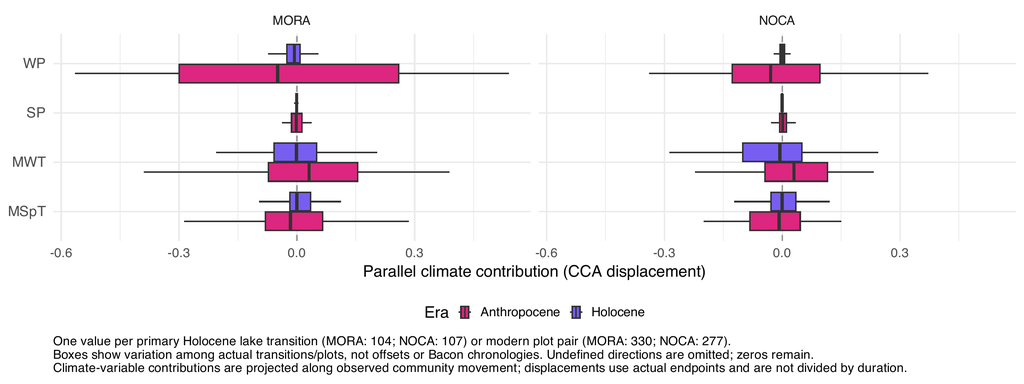

Seasonal climate displacement contributions by era and park. — PDF page 1

Stage 17 fits species models **separately within MORA and NOCA**. Holocene species rates use `climate_rate + fire_activity`, with primary MA(1) covariance and Independent/CAR1 comparisons. Anthropocene MORA species use intercept-only models (`contribution_rate ~ 1`). Anthropocene NOCA species use `contribution_rate ~ burned` with unburned as the reference. Both modern specifications use independent residuals. Each fit estimates its own residual variance; there is no site coefficient or between-park variance ratio within a park. The retained sensitivity code uses the same park separation when Bacon model sensitivity is resumed.

The coefficient PDF has separate Holocene and Anthropocene pages, with all 14 species as readable rows and coefficients (including the intercept) as columns. Blue MORA and orange NOCA estimates are shown together. The first column adds arithmetic mean parallel contributions from the same finite primary observations used in the species boxplots: each transition or plot pair counts once, zeros remain, and undefined directions are omitted. These descriptive diamonds have no model confidence intervals or significance fading; they may include responses excluded from models because a predictor is missing. Each column has its own x-axis scale. Faded estimates have unadjusted p ≥ 0.05. An `NE` marker denotes a model not estimable in that park, not a fitted zero coefficient. Species present in only one park are estimated there independently of their absence in the other park. Absent species still have zero responses throughout their park and cannot be fitted; constant responses, rank deficiency and numerical failures are reported.

The Holocene intercept is the expected contribution at zero climate-change rate and zero fire activity in the fitted park. The Anthropocene MORA intercept is the mean across all eligible plots; the NOCA intercept is the unburned mean, and its fire coefficient is burned minus unburned. No MORA fire term is fitted. The Holocene intercept remains conditional on zero predictor values. Neither an intercept nor a mean implies that all observations share its sign. Positive contributions align with climate-predicted movement; negative contributions oppose it. Captions explain park-specific absences.

| Species | Era | Park | Covariance | Converged | Selected | Failure reason |
| --- | --- | --- | --- | --- | --- | --- |
| Abies amabilis | Holocene | MORA | Independent | TRUE | FALSE | — |
| Abies amabilis | Holocene | MORA | MA1 | TRUE | TRUE | — |
| Abies amabilis | Holocene | MORA | CAR1 | TRUE | FALSE | — |
| Abies amabilis | Holocene | NOCA | Independent | FALSE | FALSE | constant_response |
| Abies amabilis | Holocene | NOCA | MA1 | FALSE | FALSE | constant_response |
| Abies amabilis | Holocene | NOCA | CAR1 | FALSE | FALSE | constant_response |
| Abies amabilis | Anthropocene | MORA | Independent | TRUE | TRUE | — |
| Abies amabilis | Anthropocene | NOCA | Independent | TRUE | TRUE | — |
| Abies grandis | Holocene | MORA | Independent | FALSE | FALSE | constant_response |
| Abies grandis | Holocene | MORA | MA1 | FALSE | FALSE | constant_response |
| Abies grandis | Holocene | MORA | CAR1 | FALSE | FALSE | constant_response |
| Abies grandis | Holocene | NOCA | Independent | FALSE | FALSE | constant_response |
| Abies grandis | Holocene | NOCA | MA1 | FALSE | FALSE | constant_response |
| Abies grandis | Holocene | NOCA | CAR1 | FALSE | FALSE | constant_response |
| Abies grandis | Anthropocene | MORA | Independent | TRUE | TRUE | — |
| Abies grandis | Anthropocene | NOCA | Independent | TRUE | TRUE | — |
| Abies lasiocarpa | Holocene | MORA | Independent | TRUE | FALSE | — |
| Abies lasiocarpa | Holocene | MORA | MA1 | TRUE | TRUE | — |
| Abies lasiocarpa | Holocene | MORA | CAR1 | TRUE | FALSE | — |
| Abies lasiocarpa | Holocene | NOCA | Independent | TRUE | FALSE | — |
| Abies lasiocarpa | Holocene | NOCA | MA1 | TRUE | TRUE | — |
| Abies lasiocarpa | Holocene | NOCA | CAR1 | TRUE | FALSE | — |
| Abies lasiocarpa | Anthropocene | MORA | Independent | TRUE | TRUE | — |
| Abies lasiocarpa | Anthropocene | NOCA | Independent | TRUE | TRUE | — |
| Abies procera | Holocene | MORA | Independent | TRUE | FALSE | — |
| Abies procera | Holocene | MORA | MA1 | TRUE | TRUE | — |
| Abies procera | Holocene | MORA | CAR1 | TRUE | FALSE | — |
| Abies procera | Holocene | NOCA | Independent | FALSE | FALSE | constant_response |
| Abies procera | Holocene | NOCA | MA1 | FALSE | FALSE | constant_response |
| Abies procera | Holocene | NOCA | CAR1 | FALSE | FALSE | constant_response |

[output cut: 82 more lines]

### Within-park species contribution means and GLS coefficients, including intercepts, by era

Separate Holocene and Anthropocene pages retain all 14 species. Blue MORA and orange NOCA diamonds show arithmetic means of finite primary contributions from the boxplot data, each transition/plot weighted equally; these descriptive means have no model intervals. Circles and capped bars show within-park GLS coefficients and conditional 95% intervals; estimates with unadjusted p ≥ 0.05 are faded. NE denotes an unavailable model in that park, with explanations in captions. Holocene intercepts are predictions at zero climate/fire predictors. Anthropocene MORA is intercept-only (overall park mean); NOCA retains burned versus unburned, with unburned as its intercept. No MORA fire coefficient is fitted. Columns have separate x-axis scales.

Script: 17_species_contribution_models.R. Complete PDF (2 pages).

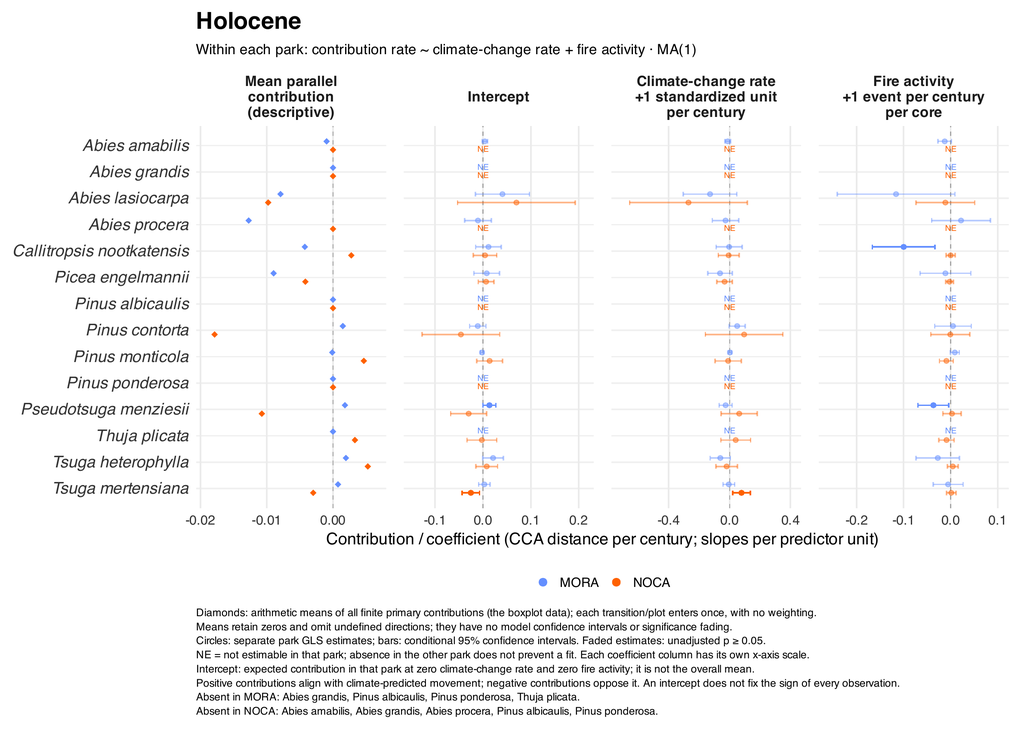

Within-park species contribution means and GLS coefficients, including intercepts, by era. — PDF page 1

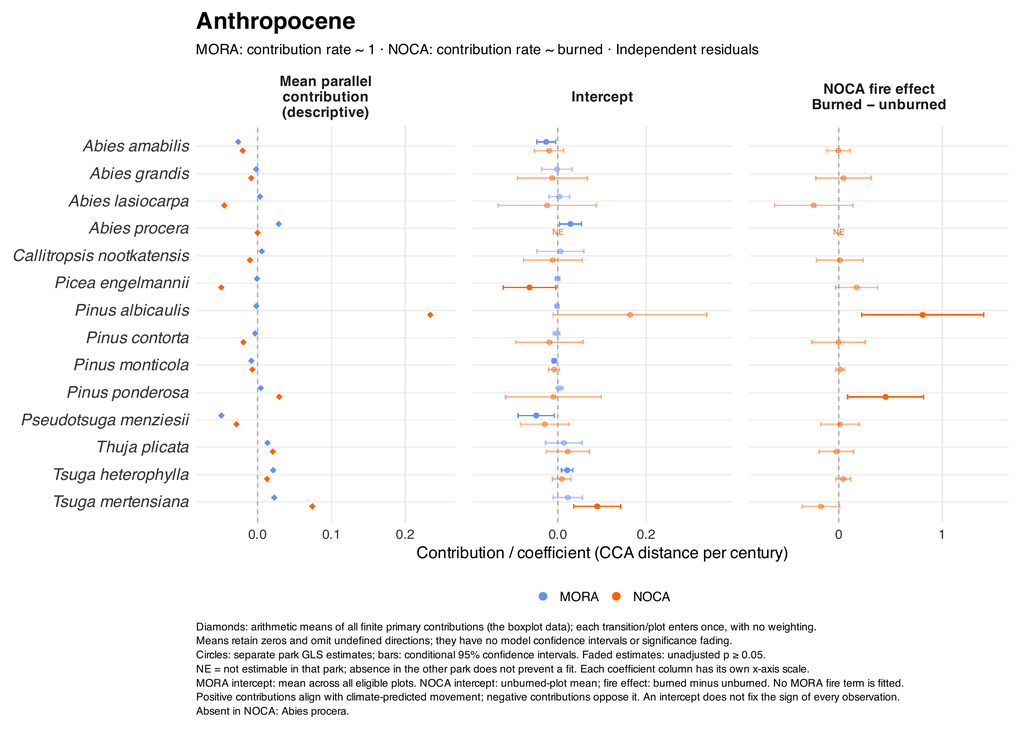

Within-park species contribution means and GLS coefficients, including intercepts, by era. — PDF page 2

### Primary species-model normalized residual diagnostics

Four pages separate Holocene MORA, Holocene NOCA, Anthropocene MORA and Anthropocene NOCA. Residuals are from each species model within that park; Bacon model sensitivity is currently on hold.

Script: 17_species_contribution_models.R. Complete PDF (4 pages).

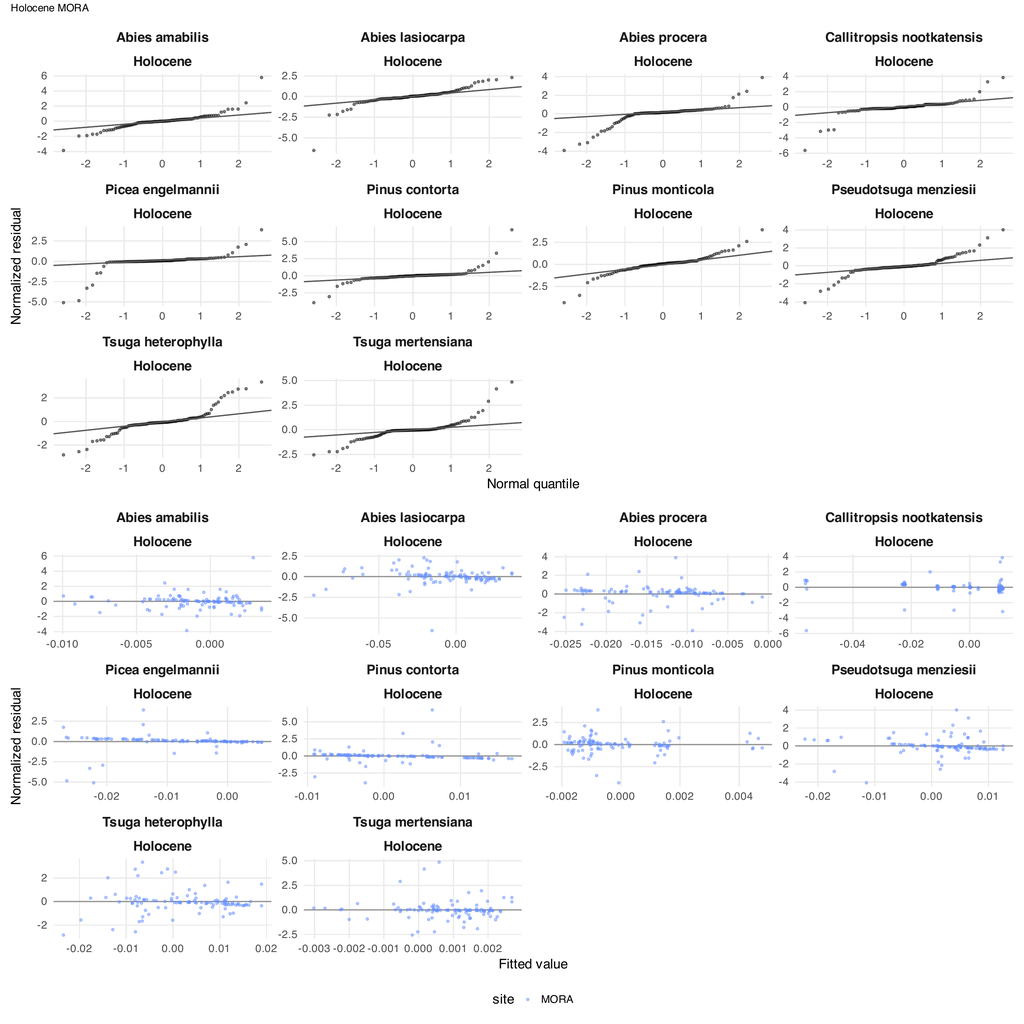

Primary species-model normalized residual diagnostics. — PDF page 1

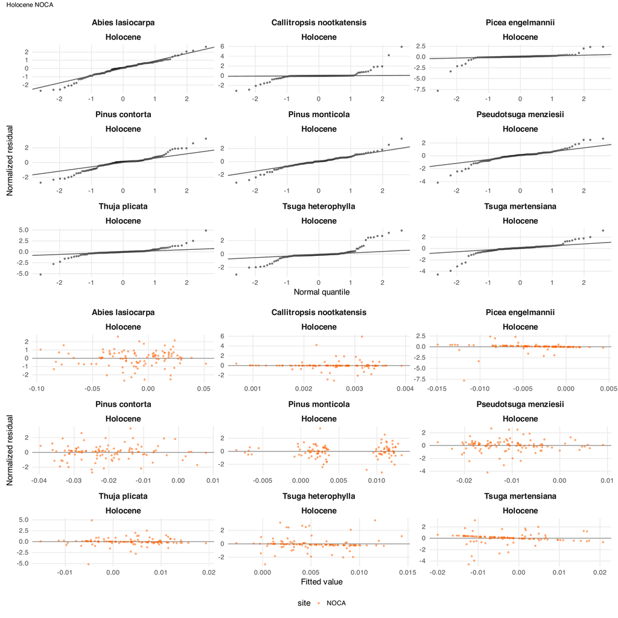

Primary species-model normalized residual diagnostics. — PDF page 2

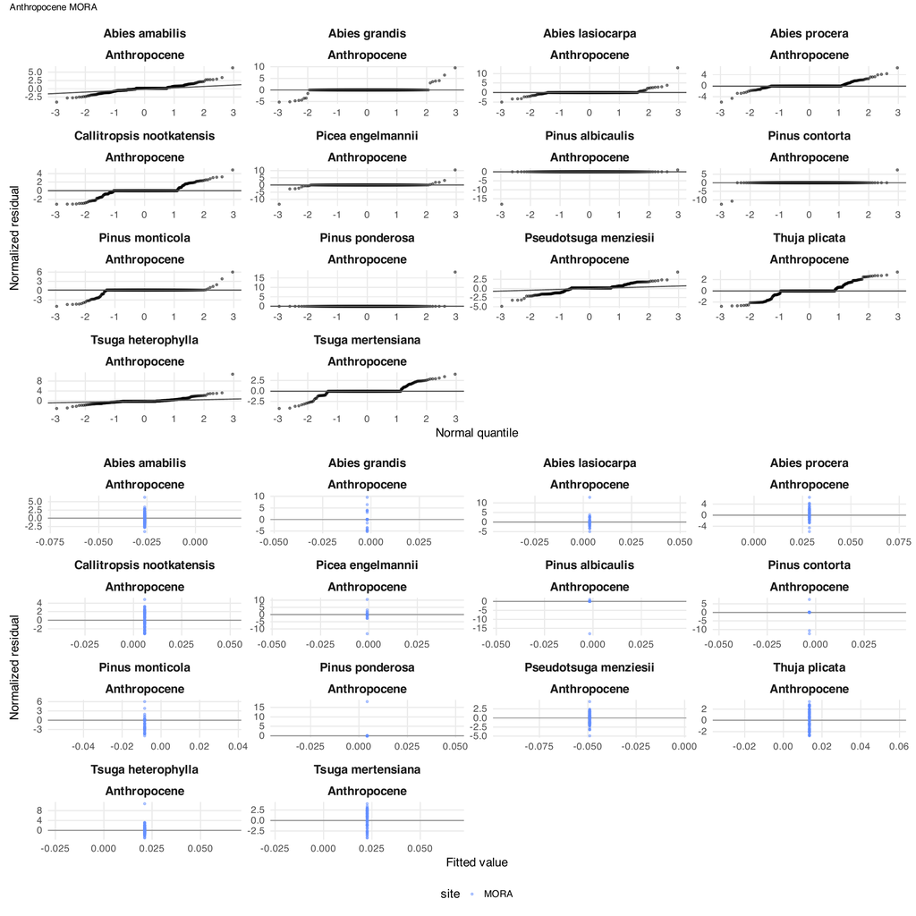

Primary species-model normalized residual diagnostics. — PDF page 3

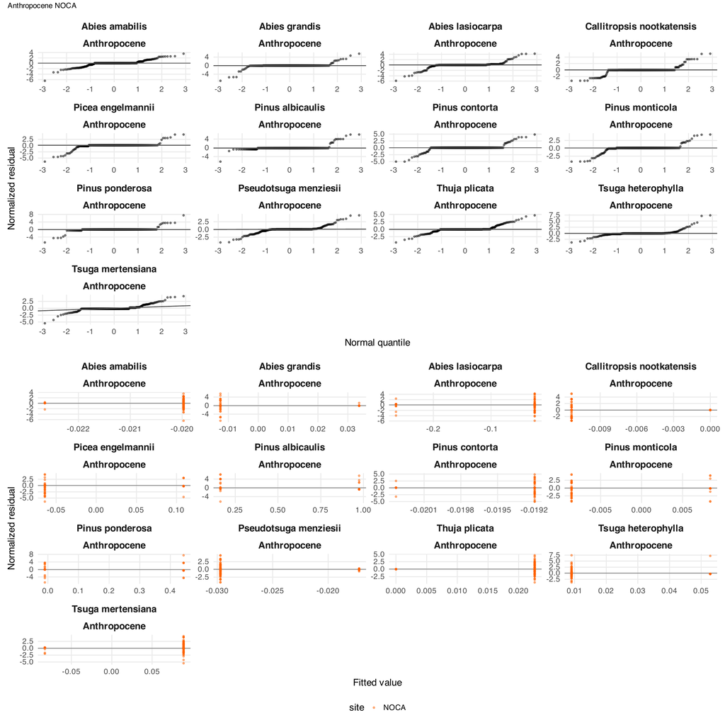

Primary species-model normalized residual diagnostics. — PDF page 4

- species occupancy
- predictor model coefficients
- predictor model performance
- predictor lake random intercept sensitivity
- predictor transition predictions
- predictor model exclusions
- predictor anthropocene elevations
- predictor model selection
- species model coefficients
- species figure coefficient availability
- species model selection
- species model performance
- predictor figure main coefficients
- predictor figure appendix coefficients
- species figure mean contributions

## Limitations and remaining questions

The chronology controls, survey windows, GPS exclusions and paired CCA eligibility are settled for this analysis. Their interpretation limits remain: conditional dating uncertainty, differing fire-proxy support, unequal survey size classes, site-confounded paleo occupancy, overlapping temporal samples and possible climate-product discontinuities.

The remaining questions below come from the scientific decision register. They distinguish planned or optional sensitivities from decisions already made.

| Question | Current choice | Consequence | Evidence needed to resolve it |
| --- | --- | --- | --- |
| Raw versus V2.1-anchored TraCE21k climate | The active Holocene analysis uses raw TraCE21k values; the V2.1 anchoring diagnostic is not authoritative. | Absolute Holocene climate levels and cross-product comparisons may retain product bias, although the active within-series change calculations are internally consistent. | A validated overlap-period comparison showing whether anchoring reduces bias without introducing a discontinuity or changing the intended anomaly interpretation. |
| Legacy-calibration versus full-record climate SDs | Changes are divided by SDs from the 607 matched legacy CCA calibration plots. | The reference is tied to the fitted model. A full-record SD would change displayed standardized magnitudes, cross-variable weighting, the unthresholded composite, and standardized climate rates, but n… | A prespecified full-record sensitivity with explicit temporal/site weighting and a scientific choice between calibration-relative and dataset-relative effect sizes. |
| Anthropocene precipitation continuity | Historical climate remains 1979–1989; modern climate uses adult Y−5 through Y at both sites (2026-10-07 decision). The MORA precipitation contrast is flagged. | The apparent post-2010 MORA precipitation shift may partly reflect CHELSA inhomogeneity rather than climate. | Independent station/reanalysis validation and a documented decision on whether post-2010 MORA precipitation is usable. The agreed years are not a pending decision. |
| Own-origin versus common-origin taxon target geometry | Deferred: the target-alignment analysis is retired. Existing CCA scores and reference matrices are preserved; the parallel contribution decomposition does not implement that separate target-origin sen… | The two cosines answer alignment relative to each trajectory’s own starting community; part of their difference can arise because LC₁ and WA₁ differ. | A prespecified common-origin sensitivity and an ecological decision about whether the estimand should condition on each starting state or hold the target vector fixed across observed and predicted mov… |

This snapshot uses verified existing analysis outputs, including stored CCA summaries and permutation tests. It does not represent a new full analysis run. Checks and rebuilding instructions.

## Diagnostic PDFs

The selected pages above show the relevant evidence; these links open the full figures. The older CHELSAcruts comparison is a historical reference, outside the current-results analysis.

| Diagnostic PDF | Purpose | Script | Shown pages | Analysis or sensitivity |
| --- | --- | --- | --- | --- |
| NOCA_cleaning.pdf | Show which NOCA plots remain after cleaning. | 000_NOCA_cleaning.R | 1 | current |
| MORA_dynamics.pdf | Show species counts before model taxon selection. | 000_MORA_cleaning.R | 3 | current |
| NOCA_dynamics.pdf | Compare corrected legacy and resurvey species counts. | 000_NOCA_cleaning.R | 3 | current |
| species_counts_consolidated.pdf | Inspect consolidated occurrence counts in each site-period group. | 000_occurrence_data_consolidate.R | 1 | current |
| stage_adult_seedling_past_present.pdf | Expose adult versus regeneration support for presence. | 000_occurrence_data_consolidate.R | 1 | current |
| species_through_time.pdf | Inspect taxon site confounding and temporal occupancy. | test_species_through_time.R | 1 | current |
| plots_to_cca.pdf | From starting plots and core samples to the CCA. | plot_sample_selection.R | 1 | current |
| fig_bacon_agedepth_slump.pdf | Inspect four fitted age-depth models and slump treatment. | 000_PALEO_a_agedepth.R | 1 | current |
| fig_bacon_pb210_sensitivity.pdf | Compare published activity errors with assumed ±10-year age uncertainty. | 000_PALEO_a_agedepth.R | 1 | chronology sensitivity |
| test_survey_year_anomaly.pdf | Compare selected survey windows with the full 1979–2021 record. | test_survey_year_anomaly.R | 1 | current |
| climate_holocene_timeseries.pdf | Inspect redundancy among candidate climate variables. | test_climate_change_variables.R | 2 | correlation diagnostic; full PDF includes 500-year sensitivity |
| fig_cca_scaling_comparison.pdf | Compare scaling 1 and 2 of the same fitted CCA. | test_cca_scaling_comparison.R | 1 | current |
| NOCA_fire_map_Wilson2024_PaleoACES.pdf | Audit NOCA modern fire assignment against Wilson reference plots. | 01_get_fire_info.R | 1 | current |
| fig_fire_event_detection_workflow.pdf | Compare fire-event detection in all four lake records. | 03_fire_event_detection_worked_example.R | 2 | current |
| fig_walsh_charanalysis_reproduction.pdf | Compare official CharAnalysis results with published Walsh totals. | 02_walsh_fire_reproduction.R | 3 | current |
| fig_holocene_climate_period_method_worked_example.pdf | Expose signed changes, phase support, and era construction. | 05_holocene_climate_fire_eras.R | 1 | current |
| fig_holocene_fire_method_worked_example.pdf | Work through centered event frequencies at 2,300 cal BP. | 06_fire_method_worked_example.R | 1 | current |
| fig_holocene_sampling_fire_100yr.pdf | Inspect macrofossil sampling and accepted fire detections on native 100-year climate cells before CCA. | 000_occurrence_data_consolidate.R | 1 | current |
| fig_method_worked_example.pdf | Work through WA/LC movement, lag, ratio, and angle. | 09_tracking_example_and_visualizations.R | 1 | current |
| fig_tracking_transition_rates.pdf | Compare tracking responses, climate and fire under established regional climate-period bands, with Anthropocene boxplots. | 09_tracking_example_and_visualizations.R | 1 | primary reconstruction; conditional inference |
| fig_tracking_transition_ratios_angles.pdf | Compare magnitude tracking ratio, angle, climate and fire under the same regional climate-period bands, one variable per row. | 09_tracking_example_and_visualizations.R | 1 | primary reconstruction; conditional inference |
| test_chelsa_cruts_vs_present.pdf | Retain the older product-comparison reference outside current results. | test_chelsa_cruts_vs_present.R | Full PDF only | historical reference |
| fig_tracking_model_group_means.pdf | Selected-covariance fitted Holocene/Anthropocene group means and contrasts for the primary reconstruction. | 12_tracking_era_models.R | 1 | primary reconstruction; conditional inference |
| fig_tracking_model_coefficients.pdf | Selected-covariance coefficients for the primary reconstruction. | 12_tracking_era_models.R | 1 | primary reconstruction; conditional inference |
| fig_tracking_model_contrasts.pdf | Selected-covariance Anthropocene-minus-Holocene contrasts for the primary reconstruction within each park. | 12_tracking_era_models.R | 1 | primary reconstruction; conditional inference |
| fig_tracking_model_residuals.pdf | Residual checks for the selected Selected-covariance for the primary reconstruction. | 12_tracking_era_models.R | 1 | primary reconstruction; conditional inference |
| fig_tracking_model_aic.pdf | Compare independent, neighboring MA(1), and continuous-time AR(1) residual covariance on identical primary observations. | 12_tracking_era_models.R | 1 | primary reconstruction; conditional inference |
| fig_tracking_lake_coefficients.pdf | Selected-covariance individual-lake coefficients for the primary reconstruction. | 13_tracking_lake_sensitivity.R | 1 | primary reconstruction; conditional inference |
| fig_tracking_lake_contrasts.pdf | Selected-covariance Anthropocene-minus-Holocene lake contrasts for the primary reconstruction. | 13_tracking_lake_sensitivity.R | 1 | primary reconstruction; conditional inference |
| fig_tracking_model_group_means.pdf | Observed turnover: Selected-covariance fitted Holocene/Anthropocene group means and contrasts for the primary reconstruction. | 12_tracking_era_models.R | 2 | primary reconstruction; conditional inference |
| fig_tracking_model_coefficients.pdf | Observed turnover: Selected-covariance coefficients for the primary reconstruction. | 12_tracking_era_models.R | 2 | primary reconstruction; conditional inference |
| fig_tracking_model_contrasts.pdf | Observed turnover: Selected-covariance Anthropocene-minus-Holocene contrasts for the primary reconstruction within each park. | 12_tracking_era_models.R | 2 | primary reconstruction; conditional inference |
| fig_tracking_model_residuals.pdf | Observed turnover: residual checks for the selected Selected-covariance for the primary reconstruction. | 12_tracking_era_models.R | 2 | primary reconstruction; conditional inference |
| fig_tracking_model_aic.pdf | Compare independent, neighboring MA(1), and continuous-time AR(1) residual covariance on identical primary observations. | 12_tracking_era_models.R | 2 | primary reconstruction; conditional inference |
| fig_tracking_lake_coefficients.pdf | Observed turnover: Selected-covariance individual-lake coefficients for the primary reconstruction. | 13_tracking_lake_sensitivity.R | 2 | primary reconstruction; conditional inference |
| fig_tracking_lake_contrasts.pdf | Observed turnover: Selected-covariance Anthropocene-minus-Holocene lake contrasts for the primary reconstruction. | 13_tracking_lake_sensitivity.R | 2 | primary reconstruction; conditional inference |
| fig_tracking_model_group_means.pdf | Untransformed physical climate-change rate: Selected-covariance fitted Holocene/Anthropocene group means and contrasts for the primary reconstruction. | 12_tracking_era_models.R | 3 | primary reconstruction; conditional inference |
| fig_tracking_model_coefficients.pdf | Untransformed physical climate-change rate: Selected-covariance coefficients for the primary reconstruction. | 12_tracking_era_models.R | 3 | primary reconstruction; conditional inference |
| fig_tracking_model_contrasts.pdf | Untransformed physical climate-change rate: Selected-covariance Anthropocene-minus-Holocene contrasts for the primary reconstruction within each park. | 12_tracking_era_models.R | 3 | primary reconstruction; conditional inference |
| fig_tracking_model_residuals.pdf | Untransformed physical climate-change rate: residual checks for the selected Selected-covariance for the primary reconstruction. | 12_tracking_era_models.R | 3 | primary reconstruction; conditional inference |
| fig_tracking_model_aic.pdf | Compare independent, neighboring MA(1), and continuous-time AR(1) residual covariance on identical primary observations. | 12_tracking_era_models.R | 3 | primary reconstruction; conditional inference |
| fig_tracking_lake_coefficients.pdf | Untransformed physical climate-change rate: Selected-covariance individual-lake coefficients for the primary reconstruction. | 13_tracking_lake_sensitivity.R | 3 | primary reconstruction; conditional inference |
| fig_tracking_lake_contrasts.pdf | Untransformed physical climate-change rate: Selected-covariance Anthropocene-minus-Holocene lake contrasts for the primary reconstruction. | 13_tracking_lake_sensitivity.R | 3 | primary reconstruction; conditional inference |
| fig_tracking_model_group_means.pdf | Pace correction effect: group means for the primary reconstruction. | 12_tracking_era_models.R | 4 | primary reconstruction; conditional inference |
| fig_tracking_model_coefficients.pdf | Pace correction effect: coefficients for the primary reconstruction. | 12_tracking_era_models.R | 4 | primary reconstruction; conditional inference |
| fig_tracking_model_contrasts.pdf | Pace correction effect: contrasts for the primary reconstruction. | 12_tracking_era_models.R | 4 | primary reconstruction; conditional inference |
| fig_tracking_model_residuals.pdf | Pace correction effect: residuals for the primary reconstruction. | 12_tracking_era_models.R | 4 | primary reconstruction; conditional inference |
| fig_tracking_model_aic.pdf | Compare independent, neighboring MA(1), and continuous-time AR(1) residual covariance on identical primary observations. | 12_tracking_era_models.R | 4 | primary reconstruction; conditional inference |
| fig_tracking_lake_coefficients.pdf | Pace correction effect: primary lake sensitivity coefficients. | 13_tracking_lake_sensitivity.R | 4 | primary reconstruction; conditional inference |
| fig_tracking_lake_contrasts.pdf | Pace correction effect: primary lake sensitivity contrasts. | 13_tracking_lake_sensitivity.R | 4 | primary reconstruction; conditional inference |
| fig_tracking_model_group_means.pdf | Direction correction effect: group means for the primary reconstruction. | 12_tracking_era_models.R | 5 | primary reconstruction; conditional inference |
| fig_tracking_model_coefficients.pdf | Direction correction effect: coefficients for the primary reconstruction. | 12_tracking_era_models.R | 5 | primary reconstruction; conditional inference |
| fig_tracking_model_contrasts.pdf | Direction correction effect: contrasts for the primary reconstruction. | 12_tracking_era_models.R | 5 | primary reconstruction; conditional inference |
| fig_tracking_model_residuals.pdf | Direction correction effect: residuals for the primary reconstruction. | 12_tracking_era_models.R | 5 | primary reconstruction; conditional inference |
| fig_tracking_model_aic.pdf | Compare independent, neighboring MA(1), and continuous-time AR(1) residual covariance on identical primary observations. | 12_tracking_era_models.R | 5 | primary reconstruction; conditional inference |
| fig_tracking_lake_coefficients.pdf | Direction correction effect: primary lake sensitivity coefficients. | 13_tracking_lake_sensitivity.R | 5 | primary reconstruction; conditional inference |
| fig_tracking_lake_contrasts.pdf | Direction correction effect: primary lake sensitivity contrasts. | 13_tracking_lake_sensitivity.R | 5 | primary reconstruction; conditional inference |
| fig_tracking_correction_effect_contrasts.pdf | Primary correction-effect era contrasts | 14_tracking_manuscript_figure.R | 1 | primary reconstruction; conditional inference |
| fig_tracking_predictor_extended_coefficients.pdf | Appendix: extended Anthropocene predictor coefficients | 15_tracking_predictor_models.R | 1 | primary reconstruction; conditional inference |
| fig_tracking_predictor_holocene_predictions.pdf | Holocene predicted lag-change trajectories | 15_tracking_predictor_models.R | 1 | primary reconstruction; conditional inference |
| fig_tracking_predictor_R2.pdf | Descriptive R² for the predictor models | 15_tracking_predictor_models.R | 1 | primary reconstruction; conditional inference |
| fig_tracking_predictor_residuals.pdf | Predictor-model normalized residual diagnostics | 15_tracking_predictor_models.R | 1 | primary reconstruction; conditional inference |
| fig_cca_transition_species_boxplots.pdf | Species contribution rates by era and park. | 16_cca_transition_contributions.R | 1 | current |
| fig_cca_transition_climate_boxplots.pdf | Seasonal climate displacement contributions by era and park. | 16_cca_transition_contributions.R | 1 | current |
| fig_species_contribution_model_coefficients.pdf | Within-park species contribution means and GLS coefficients, including intercepts, by era. | 17_species_contribution_models.R | 1, 2 | current |
| fig_species_contribution_model_residuals.pdf | Primary species-model normalized residual diagnostics. | 17_species_contribution_models.R | 1, 2, 3, 4 | current |
| fig_tracking_joint_correction_residuals.pdf | Paired pace/direction model normalized-residual diagnostics | 12_tracking_era_models.R | 1 | primary reconstruction; conditional inference |

## TraCE21k–V2.1 comparison and planned sensitivity

Climate-product comparison PDF (two pages).

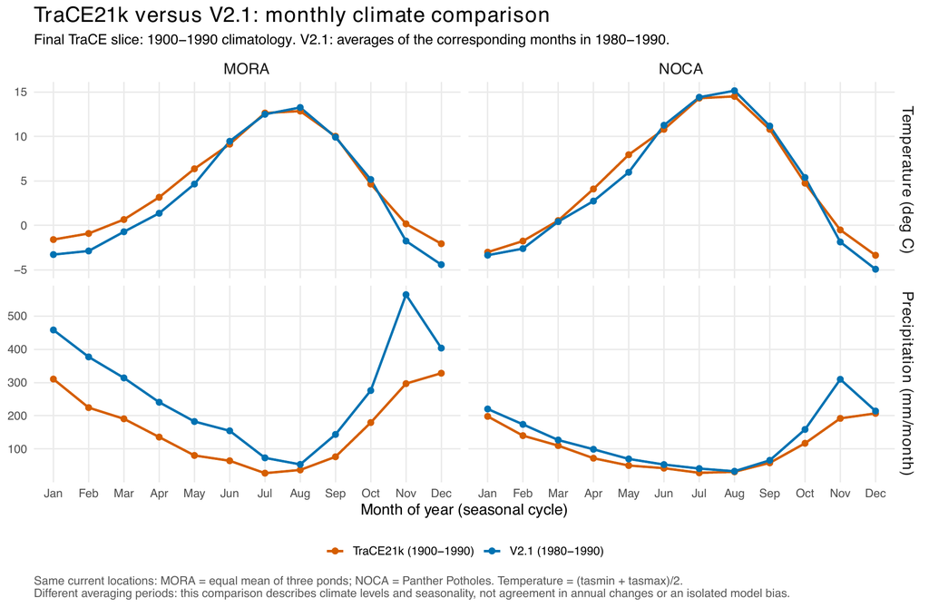

Monthly climate comparison: TraCE21k 1900–1990 versus V2.1 1980–1990 at the same pond locations — PDF page 1

This supplementary snapshot was prepared on 2026-10-07 from existing native caches at the same four pond locations. It compares the final TraCE21k slice’s **1900–1990 climatology** with **V2.1 monthly averages for 1980–1990**. MORA averages its three ponds equally; NOCA uses Panther Potholes. The averaging periods differ, so the comparison describes climate levels and seasonality rather than matched annual changes or an isolated estimate of model bias.

**Planned sensitivity — not yet performed:** Apply temperature offsets and precipitation correction factors to TraCE21k, then compare climate-change metrics, climate-predicted vegetation trajectories, Δlag and main conclusions with the current raw-TraCE21k results. Document the correction reference and factors explicitly. The current analysis remains unchanged; this comparison does not apply a correction or constitute the sensitivity analysis.